# Circular GLMM Summary: Dance States

James Foster

2026-10-22

# Details

**DESCRIPTION**

Load and plot the state-switching circular GLMM fitted in `HS_circGLMM_states.ipynb`, which assigns each dance to a forward, reversed or axial (bimodal) state and models the probability of each state as a function of condition. With `elevation: "joint"`, summarise instead the joint model fitted across solar elevation bands in `HS_circGLMM_states_joint.ipynb`, in which predictions are made for each cell (elevation band × condition). The analysis to summarise is set by `params`: the solar elevation (joint), the direction prior (bounded_vm_unrelated) and the model (states_cond_x_band), read from `params$model_dir`.

**INPUTS**

`HS_functions.R`, `0Data/hs_dance_states_<elevation>.feather`, `2Results/state_models/HS_states_<elevation>_<direction_prior>_*.nc` (`direction_prior` is the notebook’s `fit_tag`, e.g. `bounded_vm_feederbound_unrelated`, or `bounded_vm_unrelated` for the joint model)

**OUTPUTS**

Plotted estimates, predictions and contrasts.

**REFERENCES**

**sun compass and solar ephemeris**

- Dyer, F. C. (1987). Memory and sun compensation by honey bees. *Journal of Comparative Physiology A* 160, 621–633.
- Dyer, F. C., & Dickinson, J. A. (1994). Development of sun compensation by honeybees: how partially experienced bees estimate the sun’s course. *PNAS* 91, 4471–4474.
- Dyer, F. C., & Dickinson, J. A. (1996). Sun-compass learning in insects: representation in a simple mind. *Current Directions in Psychological Science* 5, 67–72.
- Lindauer, M. (1957). Sonnenorientierung der Bienen unter der Äquatorsonne und zur Nachtzeit. *Naturwissenschaften* 44, 1–6.
- New, D. A. T., & New, J. K. (1962). The dances of honeybees at small zenith distances of the sun. *Journal of Experimental Biology* 39, 271–291.
- Towne, W. F. (2008). Honeybees can learn the relationship between the solar ephemeris and a newly-experienced landscape. *Journal of Experimental Biology* 211, 3737–3743.
- Wehner, R., & Lanfranconi, B. (1981). What do the ants know about the rotation of the sky? *Nature* 293, 731–733.

**modelling methods**

- Graving JM, Sayin S, Costelloe BR, Goldshtein A & Foster JJ. Unwrapping circular statistics with Bayesian multilevel models.
- Abril-Pla, O., Andreani, V., Carroll, C., Dong, L., Fonnesbeck, C. J., Kochurov, M., Kumar, R., Lao, J., Luhmann, C. C., Martin, O. A., et al. (2023). `PyMC`: a modern, and comprehensive probabilistic programming framework in Python. *PeerJ Computer Science* 9, e1516.
- Seyboldt, A., Carlson, E. L., & Carpenter, B. (2026). Preconditioning Hamiltonian Monte Carlo by minimizing Fisher Divergence. *arXiv* preprint arXiv:2603.18845.
- Yao, Y., Vehtari, A., & Gelman, A. (2022). Stacking for non-mixing Bayesian computations: the curse and blessing of multimodal posteriors. *Journal of Machine Learning Research* 23(79), 1-45.

# Motivation

On a horizontal comb, and under some skylight conditions, honeybee dances are not always oriented in a single direction relative to the feeder: some dances point away from the feeder (reversed), and others alternate between two opposite directions (axial). Rather than describing these by a continuous mixture weight, each dance is assigned to one of three latent states:

| state | density of each waggle run |
| --- | --- |
| forward | $\mathcal{M}(\theta \mid \mu_d, \kappa_d)$ |
| reversed | $\mathcal{M}(\theta \mid \mu_d + \pi, \kappa_d)$ |
| axial | $w\,\mathcal{M}(\theta \mid \mu_d, \kappa_d) + (1-w)\,\mathcal{M}(\theta \mid \mu_d + \pi, \kappa_d)$, $0.25 < w < 0.75$ |
| disoriented (optional) | $1 / 2\pi$ |

The probability of each state is modelled with a multinomial logit (forward as reference), with condition effects and individual random effects:

$\log(\pi_\text{reversed} / \pi_\text{forward}) \sim$ condition + (1 |Individual)

$\log(\pi_\text{axial} / \pi_\text{forward}) \sim$ condition + (1 |Individual)

The forward direction of each dance, $\mu_d$, combines a direction for its condition with individual and dance offsets, and the concentration, $\kappa_d$, has condition effects and individual and dance random effects. Condition effects are coded as successive differences, vertical → horizontal → antisolar → solar (H, A, S), as in `HS_circGLMM_fit_4cond.ipynb`. To keep reversals from being described by 180° changes in direction, condition directions and dance offsets are bounded (see `HS_circGLMM_states.ipynb`), and individual offsets have a strongly concentrated von Mises prior ($\kappa_u \sim \text{LogNormal}(\log 30, 0.6)$). In fits before 2026 10 21, chains that settled in poor local optima (mean log posterior more than 20 below the best chain) were dropped before saving; from the `feederbound` fits on, such chains are only reported (see *Model development* below).

## Model development

The aim is a model whose chains all agree without any being rejected, as a basis for a joint model across solar elevations. Steps so far, and why:

1. **Direction priors.** Unbounded direction priors (`soft`, `vonmises`) let condition or dance offsets grow to about 180°, imitating a reversal, so chains disagreed. Bounding directions with $B \tanh(x / B)$ (`bounded`) converged at low elevation, but at high elevation the vertical direction traded off against Normal individual offsets. The current default, `bounded_vm`, keeps bounded condition directions and dance offsets but uses strongly concentrated von Mises individual offsets.
2. **High elevation, `bounded_vm` (2026 10 21).** The two-state model converged after chain screening, but the three-state models did not ($\hat{R}$ 1.3–1.4 for the vertical direction), and 2–4 of 8 chains per model were dropped. Two problems were identified:
   - *Far-off chains* (mean log posterior 300–600 below the best) had condition directions near −90° to −105° and very low concentration. Condition directions were bounded relative to the population direction (each within 60° of it, which was itself within 60° of the feeder), so a condition could be up to 120° from the feeder: a “forward” direction pointing away from it. These chains had also started from nutpie’s default initial values (zero on the latent scale, i.e. very low concentration and equal state probabilities).
   - *Near chains* (5–8 below the best) were caused by a single vertical dance (`69r_00028`, 10 runs, mean −72°, sun elevation 84°), beyond the 60° offset bound from the other vertical dances (+2° to +31°, mean +14°). In most chains it was described as forward, pulling the vertical direction to −7°; in others it was described as reversed, with the vertical direction at +17° to +35°. Near the zenith a small error in time or position gives a large error in solar azimuth, so this is probably an ephemeris failure rather than a genuine dance direction.
3. **Fixes tested at high elevation (`fit_tag` `bounded_vm_feederbound_disoriented`).**
   - *Condition directions bounded relative to the feeder* (`condition_bound = 'feeder'`): each condition’s forward direction is within 60° of the feeder, which is what “forward” means in this design, so the far-off configurations are excluded. This is the same constraint an arctan transform or a scaled Beta prior would impose, applied to the condition direction itself rather than cumulatively.
   - *A disoriented state* (`outlier_state = 'disoriented'`): runs uniformly distributed, with an intercept-only logit (prior mean −2), for the few dances whose directions are unrelated to the feeder (e.g. ephemeris failures). Reviewers may also ask whether such dances are present.
   - *Data-based initial values* (`data_inits = TRUE`): chains start near condition directions estimated from the dances’ axes and a concentration estimated from their mean resultant lengths (nutpie still jitters each chain’s start), and flagged chains are reported but not dropped.

   Result (three-state condition-dependent model, 8 chains, none dropped): no chain was far off (mean log posteriors within 11 of each other), there were no divergences, and all chains agreed on the horizontal, antisolar and solar directions, concentrations, state effects and offset SDs ($\hat{R} \le 1.02$); sampling took about 7 minutes rather than about 20. The vertical direction still mixed slowly ($\hat{R} = 1.18$; chain means −8° to +12°), because the outlying dance alternated between forward at −57° (pulling the vertical direction to −7°) and disoriented (vertical direction +8° to +11°). A uniform state describes it poorly: its runs are tightly clustered ($R = 0.87$), just not around the feeder, as expected for an ephemeris failure. Also, with an intercept-only logit against forward, the disoriented probability was proportional to the forward probability, so it was lower in conditions with many reversed dances (e.g. solar), which was not intended.
   - *An “unrelated direction” state* (`outlier_state = 'unrelated'`) replaces the uniform state: runs keep the dance’s concentration, around a direction $\nu_d$ unrelated to the feeder. Marginalising over a uniform $\nu_d$ gives a closed form, $I_0(\kappa_d R_d) / (2\pi I_0(\kappa_d))^{n_d}$, with no extra parameters. Its probability is a single parameter for all dances, with the other states sharing the remainder.

   Result (`fit_tag` `bounded_vm_feederbound_unrelated`, 8 chains, none dropped, no divergences, about 6 minutes): all chains agreed on every condition direction, including vertical (chain means +13° to +16°; +14°, 95% CI +4° to +26°, $\hat{R} = 1.01$), matching the vertical dances other than `69r_00028`, which was assigned to the unrelated state with probability 1.00. However, the unrelated state took more than a few dances: its probability was 0.13 (95% CI 0.03–0.29), about 13 dances’ worth, including several rotated 45°–160° from their condition (e.g. horizontal dances at +46°, +119°, +126°, −143°; solar dances at +159°, −177°), all with the sun above 76°. The dance offset SD halved (0.47 to 0.24 rad), as these dances were no longer described by large offsets, and it now mixes slowly (bulk ESS 79), as does the unrelated probability. Short dances were not absorbed (mean probability 0.07 for dances with ≤ 3 runs). So at high elevation the unrelated state describes a real feature of the data, dances rotated well away from the feeder with the sun near the zenith, and not only ephemeris failures; whether these are errors in the ephemeris or by the bees affects how the state should be interpreted.
4. **Possible causes of unrelated dances, and condition effects.** Our own calculation of solar azimuth cannot explain them in most conditions: in `HS_OrganiseData.Rmd`, `feeder_angle` depends on the computed solar azimuth only for vertical dances; for horizontal, antisolar, solar and zenith dances (compass bearings) it cancels out. All non-vertical dances in the unrelated state passed compass calibration (`ok`, one with `only_one_annotation`). A more likely cause is the bees’ own internal model of the solar ephemeris, which may differ from the true function, particularly near the zenith, and appears to vary more towards the end of the day, when the sun falls behind vegetation (an observation from these experiments; we found no published report of this). In the published literature:
   - Inexperienced honeybees use an innate step-like ephemeris: the sun approximately stationary all morning, about 180° from its average afternoon azimuth, switching around local noon (Dyer & Dickinson 1994). Bees dancing through midday rotated their dances progressively, not instantaneously, which suggests a continuous function. With experience the representation comes to follow the true ephemeris (Dyer 1987; Dyer & Dickinson 1996; Towne 2008).
   - No bee study describes an ephemeris with only “slow” and “fast” speeds of azimuth change. In ants, the representation is a smoothed version of the true function, with the fast midday rates underestimated (Wehner & Lanfranconi 1981).
   - Near the zenith, dances become inaccurate: within about 10° of the zenith they deviated widely and often turned the wrong way, while remaining well oriented (New & New 1962), and within about 2.5° they were disoriented (Lindauer 1957). These are the conditions of our high-elevation group (sun 76°–84°, 6°–14° from the zenith), so oriented dances far from the feeder would be expected there. That would affect all conditions, possibly to different extents, so the probability of the unrelated state is given condition effects (`outlier_effects = TRUE`, `fit_tag` `bounded_vm_feederbound_unrelated_cond`), as for the other states.

   Result (high elevation, 8 chains, none dropped, no divergences): directions as without condition effects (vertical +14°, 95% CI +3° to +24°), and the condition effects on the unrelated probability were weak and uncertain: 0.10 (vertical), 0.21 (horizontal), 0.21 (antisolar), 0.14 (solar), with wide intervals (e.g. horizontal − vertical +0.10, 95% CI −0.08 to +0.39, P(>0) = 0.80). With about 9 dances assigned to the unrelated state at this elevation, condition differences cannot be resolved; the joint model, with more dances, is a better test. The unrelated state also competes with the reversed and axial states in the horizontal condition, so the increase in reversed dances from vertical to horizontal became less certain (P(>0) = 0.87, compared with 0.999 without an unrelated state); the solar increase was unaffected (P(>0) = 1.00). The dance offset SD and the unrelated effects mixed slowly (max $\hat{R} = 1.11$, min bulk ESS 49), so the final fits will need longer runs.

   The unimodal null model (forward only) was first fitted with the bounded direction priors, which cannot describe a reversal at all (its horizontal and solar directions sat at the ±60° bound), so that comparison was not a fair test. With unbounded von Mises priors instead (`direction = 'vonmises'`: population direction VonMises(0, 5), condition effects VonMises(0, 2), individual offsets with $\kappa_u \sim \text{LogNormal}(\log 30, 0.6)$, dance offsets with $\kappa_v \sim \text{LogNormal}(\log 5, 0.5)$), reversed dances can be described by large offsets and axial dances by low concentration, as in the `GUVdances` models. This null model converged well (8 chains, none dropped, no divergences, max $\hat{R} = 1.02$). It describes the horizontal and solar conditions by rotating their population directions (+128° and −151°, i.e. mostly away from the feeder), with a dance offset SD of 0.75 rad (43°) and 24% of dances offset by more than 45°. On PSIS-LOO it scored *better* than the state model ($\Delta\text{elpd} = +47$, SE 13), but this is not reliable: 78 of 92 dances had Pareto $\hat{k} > 0.7$ for the null model (53 of 92 for the state model), and high $\hat{k}$ usually means the PSIS estimate is optimistic. K-fold cross-validation over dances (or individuals) is therefore needed before comparing the state and null models.
5. **Next: a joint model across elevations.** Vertical dances should point towards the feeder at all elevations (a central part of the study design), so the vertical direction can be shared across elevations, with about 100 vertical dances rather than 21 at high elevation; a single outlying dance then has little influence. State probabilities, including that of the unrelated state, would depend on condition and elevation, since the causes above are best accounted for jointly. For model comparison, start with the three elevation bands with most data (low, medium, high) and build towards a continuous effect of sun elevation. The null model, with only unimodal (forward) dances as in the `GUVdances` analysis, is included in the comparison (`unimodal`).
6. **Joint model across elevation bands (`HS_circGLMM_states_joint.ipynb`, fitted 2026 10 22).** All dances in the low ($< 15°$), medium ($30°$–$45°$) and high ($> 75°$) bands are fitted together: 312 dances by 35 bees, 19 of which danced in more than one band. Effects are coded per dance from named terms, condition (`H`, `A`, `S`, successive differences), band (`low`, `high`, relative to `medium`) and their interactions where there are data, so that a continuous effect of sun elevation can replace the bands later. Directions follow `condition + condition:band`, so the vertical direction is the same in every band; concentration follows `condition * band`; the unrelated state is included, with the same effects as the other state probabilities. Five models were compared, differing in their state probabilities: `states_cond` (condition only), `states_cond_band` (condition + band), `states_cond_x_band` (condition × band), `states_cond_x_band_fixed` (condition × band, every cell’s direction fixed at the feeder) and the `unimodal` null model (unbounded von Mises directions).

   Result (4 chains of 1000 draws after 1000 tuning steps, data-based initial values, no chains dropped): no divergences in any model, chains agreed (mean log posteriors within 15 of each other), max $\hat{R}$ 1.03–1.07, the largest values for single dances rather than population parameters. Cell directions agreed between chains within about 5° and between the state models within a few degrees: vertical +9° in every band, horizontal −22° (low), −24° (medium), −19° (high), antisolar −4° (medium) and +26° (high), solar +27° (medium) and +29° (high). Individual differences in the reversed probability were small (`reversed_Individual_sigma` median 0.22–0.26, below the prior median of 0.67), while those in the axial probability were poorly identified (median 0.43–0.58, close to the prior).

   On PSIS-LOO (see *Model comparison*), the two models with band effects on the state probabilities were best and indistinguishable (`states_cond_band` elpd −2579, `states_cond_x_band` −1, SE 8), and both were better than condition-only state probabilities (−28, SE 9) and than fixed directions (−38, SE 13); the unimodal model could not be distinguished (−28, SE 47). As before, these estimates are unreliable (Pareto $\hat{k} > 0.7$ for 236–270 of 312 dances), so leave-individuals-out (grouped K-fold) cross-validation is needed before drawing conclusions, particularly for states versus the unimodal null model: see `HS_circGLMM_states_joint_kfold.ipynb` (about 3.5 hours per fold for four models on a 16 GB PC).

# Set up workspace

To extract these models, we need to load the appropriate functions. Make sure that the `circular`, `reticulate`, `arrow`, `posterior` and `bayesplot` packages are installed. Here we use the `HS-env` conda environment created for `HS_circGLMM_fit_4cond.ipynb`, so that `arviz` can read the saved model. If it does not exist yet, create it from a terminal with conda available (e.g. Anaconda Prompt):

`conda create -n HS-env python=3.12 -c conda-forge -y`

`conda activate HS-env`

`pip install -r nutpie_unwrap_requirements.txt`

`reticulate` cannot always find the conda binary (e.g. RStudio on Windows with an “All Users” install in `C:/ProgramData`), so we search the usual install locations. To use a different conda binary or environment, set `RETICULATE_CONDA` or `HS_CONDA_ENV` in your `~/.Renviron`.

```r
source('HS_functions.R')
require(reticulate) #run python from R
#conda environment in which the model was fitted
hs_env = Sys.getenv('HS_CONDA_ENV', unset = 'HS-env')
#find the conda binary, unless the user has specified one
if(!nzchar(Sys.getenv('RETICULATE_CONDA')))
{
  conda_roots = c(Sys.getenv(c('USERPROFILE', 'LOCALAPPDATA', 'ProgramData', 'HOME')),
                  '/opt', '/usr/local')
  conda_dists = c('anaconda3', 'miniconda3', 'miniforge3', 'mambaforge')
  conda_bins = if(.Platform$OS.type == 'windows'){'Scripts/conda.exe'}else{'bin/conda'}
  conda_candidates = c(Sys.getenv('CONDA_EXE'), #set inside an activated conda shell
                       Sys.which('conda'), #on the PATH
                       file.path(rep(conda_roots[nzchar(conda_roots)],
                                     each = length(conda_dists)),
                                 conda_dists,
                                 conda_bins)
                       )
  conda_found = Filter(function(x){nzchar(x) & file.exists(x)},
                       conda_candidates)
  if(length(conda_found))
  {
    Sys.setenv(RETICULATE_CONDA = normalizePath(conda_found[1], winslash = '/'))
  }
}
#use the environment, with instructions if it cannot be found
tryCatch(use_condaenv(hs_env, required = TRUE),
         error = function(e)
         {
           stop('Could not use conda environment "', hs_env, '": ', conditionMessage(e),
                '\nCreate it (see above), or set RETICULATE_CONDA to the path of your conda binary.',
                call. = FALSE)
         }
         )
reticulate::py_config()
```

```
## python:         C:/Users/James Foster/.conda/envs/HS-env/python.exe
## libpython:      C:/Users/James Foster/.conda/envs/HS-env/python312.dll
## pythonhome:     C:/Users/James Foster/.conda/envs/HS-env
## version:        3.12.15 | packaged by conda-forge | (main, Oct 13 2026, 16:44:09) [MSC v.1944 64 bit (AMD64)]
## Architecture:   64bit
## numpy:          C:/Users/James Foster/.conda/envs/HS-env/Lib/site-packages/numpy
## numpy_version:  1.26.4
##
## NOTE: Python version was forced by use_python() function
```

```r
#load .feather files (readable in R and Python)
require(arrow)
```

```r
#process and plot MCMC data
require(posterior)
require(bayesplot)
options(posterior.num_args = list(sigfig = 3))#for ease of reading

#condition colours, as in HS_ExploratoryPlots.Rmd
cond_cols = list(
  vertical = 'darkred',
  horizontal = 'darkgreen',
  antisolar = 'cyan4',
  solar = 'blue4'
)
#state colours
state_cols = list(
  forward = '#1b7837',
  reversed = '#762a83',
  axial = '#e08214',
  unrelated = '#808080',
  disoriented = '#808080'
)
states = names(state_cols)
#successive model effects for each condition
cond_effs_all = list(vertical = character(0),
                     horizontal = c('H'),
                     antisolar = c('H', 'A'),
                     solar = c('H', 'A', 'S'))
#joint model across elevation bands: predictions for each cell (band x condition)
joint = params$elevation == 'joint'
bands_all = c('low', 'medium', 'high')
```

# Prepare data

Load the data in the exact form used to fit the model, saved by `HS_circGLMM_states.ipynb` (or `HS_circGLMM_states_joint.ipynb`) as a `.feather` file (readable in both `R` and `Python`). Dances and individuals are numbered from 0 in the order of their labels, matching the model’s coordinates. Predictions are made for each *group*: a condition for a single elevation, or a cell (elevation band × condition) for the joint model.

```r
hd = read_feather(file = file.path('0Data',
                                   paste0('hs_dance_states_', params$elevation, '.feather')))
hd = as.data.frame(hd)
hd = within(hd,
            {
              condition = droplevels(factor(as.character(condition),
                                            levels = names(cond_cols)))
              band = if(joint){factor(as.character(band), levels = bands_all)}else{params$elevation}
              angle_deg = deg(angle) # in degrees, for plotting
            }
)
conds = levels(hd$condition)
#groups: conditions, or cells (band_condition) in band then condition order, as in the model
group_tab = if(joint)
{
  gt = unique(hd[, c('band', 'condition')])
  gt = gt[order(gt$band, gt$condition), ]
  data.frame(group = paste(gt$band, gt$condition, sep = '_'),
             band = as.character(gt$band), condition = as.character(gt$condition))
}else
{
  data.frame(group = conds, band = params$elevation, condition = conds)
}
groups = group_tab$group
rownames(group_tab) = groups
hd$group = factor(if(joint){paste(hd$band, hd$condition, sep = '_')}else{as.character(hd$condition)},
                  levels = groups)
#colour of each group: that of its condition
GroupCol = function(g){cond_cols[[group_tab[g, 'condition']]]}
#one row per dance (0-based codes, as in the model)
dance_tab = unique(hd[, c('Dance', 'Dance_label', 'Individual', 'Individual_label', 'condition', 'group')])
dance_tab = dance_tab[order(dance_tab$Dance), ]
id_tab = unique(hd[, c('Individual', 'Individual_label')])
id_tab = id_tab[order(id_tab$Individual), ]
n_dance = nrow(dance_tab)
n_ind = nrow(id_tab)
#which individuals danced in which groups (rows ordered by Individual)
id_group = sapply(groups,
                  function(g)
                  {
                    id_tab$Individual %in% subset(hd, group %in% g)$Individual
                  }
                  )
print(paste('Elevation:', params$elevation, '; groups:', paste(groups, collapse = ', ')))
```

```
## [1] "Elevation: joint ; groups: low_vertical, low_horizontal, medium_vertical, medium_horizontal, medium_antisolar, medium_solar, high_vertical, high_horizontal, high_antisolar, high_solar"
```

```r
#runs, dances and individuals per group
aggregate(cbind(runs = angle) ~ group, data = hd, FUN = length)
```

```
##                group runs
## 1       low_vertical  382
## 2     low_horizontal  556
## 3    medium_vertical  638
## 4  medium_horizontal  395
## 5   medium_antisolar  226
## 6       medium_solar  159
## 7      high_vertical  233
## 8    high_horizontal  145
## 9     high_antisolar  362
## 10        high_solar  270
```

```r
with(unique(hd[, c('Individual_label', 'Dance_label', 'group')]),
     table(Individual_label, group))
```

```
##                 group
## Individual_label low_vertical low_horizontal medium_vertical medium_horizontal
##              11r            1              0               3                 0
##              16b            0              0               1                 0
##              17y            2              2               0                 0
##              20y            3              9               5                 5
##              22b            4              6              12                 5
##              23y            2              3               1                 4
##              25y            0              1               0                 1
##              26y            0              0               0                 2
##              46b            0              0               0                 0
##              47y            6              4               1                 2
##              48b            0              0               1                 0
##              58r            0              0               2                 0
##              60r            1              1               2                 1
##              62b            0              2               0                 0
##              65r            0              0               1                 0
##              66b            2              0               0                 4
##              69r            0              0               0                 1
##              73b            1              7               7                 3
##              80b            0              0               1                 0
##              80r            0              0               0                 0
##              80w            0              0               0                 0
##              81r            2              5               0                 1
##              82b            0              1               0                 0
##              84b            5              6               3                 4
##              84r            1              1               2                 0
##              85b            0              0               0                 0
##              87r            0              0               3                 0
##              88b            0              1               1                 3
##              88y            0              0               0                 0
##              90r            1              8               2                 3
##              92w            0              1               0                 0
##              94w            0              0               0                 1
##              95r            2              7               0                 0
##              97r            0              0               0                 0
##              9b             1              0               0                 0
##                 group
## Individual_label medium_antisolar medium_solar high_vertical high_horizontal
##              11r                0            0             1               1
```

[output cut: 56 more lines]

```
##              80w              1          0
##              81r              1          1
##              82b              0          0
##              84b              0          1
##              84r              0          0
##              85b              0          0
##              87r              3          0
##              88b              0          0
##              88y              1          0
##              90r              4          3
##              92w              0          0
##              94w              0          0
##              95r              1          3
##              97r              0          0
##              9b               0          1
```

# Load model and extract draws

This loads draws from the fitted model’s posterior distribution, using the `reticulate` package to read the `Python` `arviz` file. Each parameter is extracted as an array of samples $\times$ levels (with draws running sequentially within each chain), and population-level parameters are collected into a `draws_df` for trace plots.

```r
az = reticulate::import("arviz")
model_file = file.path(params$model_dir,
                       paste0('HS_states_', params$elevation, '_', params$direction_prior, '_',
                              params$model, '.nc'))
print(model_file)
```

```
## [1] "2Results/state_models/HS_states_joint_bounded_vm_unrelated_states_cond_x_band.nc"
```

```r
idata = az$from_netcdf(model_file)
post = idata$posterior
post_vars = unlist(reticulate::iterate(post$data_vars$keys()))
n_chains = as.integer(post$sizes['chain'])
n_draws = as.integer(post$sizes['draw'])
n_samp = n_chains * n_draws

#Extract a parameter as samples (x levels (x levels)), draws within chains
Draws = function(name)
{
  vals = reticulate::py_get_item(post, name)$values
  d = dim(vals)
  if(length(d) == 2)
  {
    as.vector(t(vals))
  }else if(length(d) == 3)
  {
    matrix(aperm(vals, c(2, 1, 3)), ncol = d[3])
  }else
  {
    array(aperm(vals, c(2, 1, 3, 4)), dim = c(n_samp, d[3], d[4]))
  }
}
#Coordinates of a dimension
Coords = function(dim_name)
{
  as.character(reticulate::py_get_item(post$coords, dim_name)$values)
}
model_states = Coords('state')
#an outlier state (unrelated or disoriented) has its own probability, without individual effects
outlier_states = intersect(model_states, c('unrelated', 'disoriented'))
main_states = setdiff(model_states, outlier_states)
stopifnot(all(Coords('dance') == dance_tab$Dance_label),
          all(Coords(if(joint){'cell'}else{'condition'}) == groups))
#names of the effects (terms) on concentration and on the state logits:
#successive condition differences (H, A, S) and, for the joint model, band effects (low, high) and their interactions
coord_names = unlist(reticulate::iterate(post$coords$keys()))
TermNames = function(joint_dim)
{
  if(joint){Coords(joint_dim)}else if('effect' %in% coord_names){Coords('effect')}else{unique(unlist(cond_effs_all[conds]))}
}
kappa_terms = if('kappa_effect' %in% post_vars){TermNames('kappa_effect_term')}else{character(0)}
state_terms = if(any(paste0(model_states, '_effect') %in% post_vars)){TermNames('state_effect_term')}else{character(0)}

#population-level parameters
mu_grp = Draws(if(joint){'mu_cell'}else{'mu_condition'}) # samples x groups
colnames(mu_grp) = groups
kappa0 = Draws('kappa_Intercept')
kappa_eff = if(length(kappa_terms)){Draws('kappa_effect')}else{NULL}
state_int = lapply(setNames(model_states[-1], model_states[-1]),
                   function(s){Draws(paste0(s, '_Intercept'))})
state_eff = lapply(setNames(main_states[-1], main_states[-1]),
                   function(s)
                   {
                     nm = paste0(s, '_effect')
                     if(nm %in% post_vars){m = Draws(nm); colnames(m) = state_terms; m}else{NULL}
                   })
out_eff = if(length(outlier_states) && paste0(outlier_states, '_effect') %in% post_vars)
{
  m = Draws(paste0(outlier_states, '_effect')); colnames(m) = state_terms; m
}else{NULL}
w_axial = if('w_axial' %in% post_vars){Draws('w_axial')}else{rep(0.5, n_samp)}
#group-level parameters
mu_dance = Draws('mu') # samples x dances: forward direction of each dance
kappa_dance = Draws('kappa') # samples x dances
p_state = Draws('p_state') # samples x dances x states: posterior state probabilities
ind_state_z = lapply(setNames(main_states[-1], main_states[-1]),
                     function(s)
                     {
                       sweep(Draws(paste0(s, '_Individual_z')), 1,
                             Draws(paste0(s, '_Individual_sigma')), '*')
                     })
#individual direction offsets: von Mises or non-centred Normal, depending on the direction prior
mu_ind = if('mu_Individual' %in% post_vars)
{
  Draws('mu_Individual')
}else
{
  sweep(Draws('mu_Individual_z'), 1, Draws('mu_Individual_sigma'), '*')
}
#the unimodal null model has unbounded (von Mises) directions
bounded_dirs = grepl('bounded', params$direction_prior) & params$model != 'unimodal'

#trace-plot data frame of population-level parameters (interaction terms such as H:high named H.high)
TermLabel = function(e){gsub(':', '.', e)}
draws_list = list(.chain = rep(1:n_chains, each = n_draws),
                  .iteration = rep(1:n_draws, times = n_chains))
for(g in groups){draws_list[[paste0('mu_', g)]] = mu_grp[, g]}
draws_list$kappa_Intercept = kappa0
for(e in kappa_terms){draws_list[[paste0('kappa_', TermLabel(e))]] = kappa_eff[, which(kappa_terms == e)]}
for(s in names(state_int))
{
  draws_list[[paste0(s, '_Intercept')]] = state_int[[s]]
  for(e in state_terms){if(!is.null(state_eff[[s]])){draws_list[[paste0(s, '_', TermLabel(e))]] = state_eff[[s]][, e]}}
}
for(e in colnames(out_eff)){draws_list[[paste0(outlier_states, '_', TermLabel(e))]] = out_eff[, e]}
draws_list$w_axial = w_axial
for(nm in c('mu_Individual_sigma', 'mu_Dance_sigma', 'kappa_Individual_sigma', 'kappa_Dance_sigma',
            'reversed_Individual_sigma', 'axial_Individual_sigma'))
{
  if(nm %in% post_vars){draws_list[[nm]] = Draws(nm)}
}
draws_final = posterior::as_draws_df(as.data.frame(draws_list, check.names = FALSE))
```

# Inspect model estimates

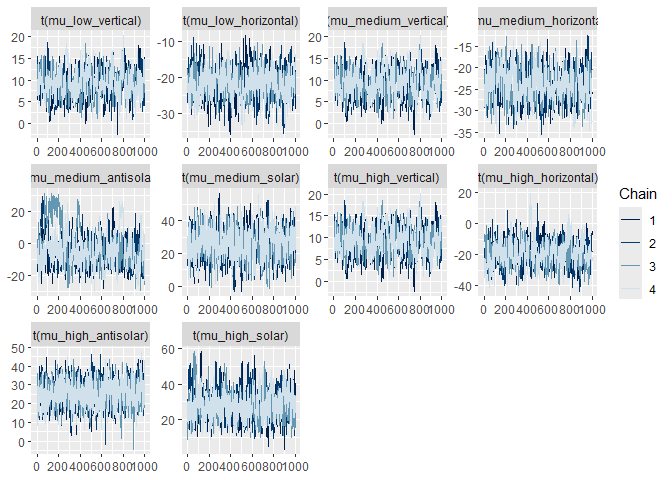

```r
mcmc_trace(draws_final,
           pars = paste0('mu_', groups),
           transformations = unwrap_circular_deg)
```

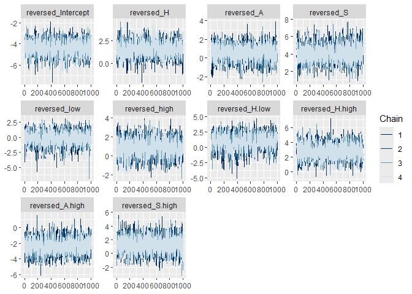

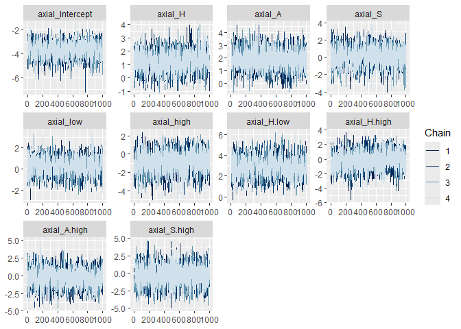

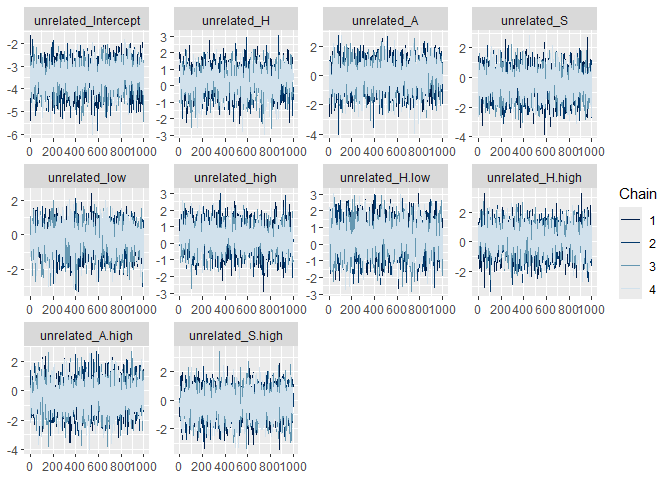

```r
term_pattern = '(Intercept|[HAS]|low|high|[HAS]\\.(low|high))$'
for(s in names(state_int))
{
  print(mcmc_trace(draws_final,
                   pars = grep(paste0('^', s, '_', term_pattern), names(draws_final), value = TRUE)))
}
```

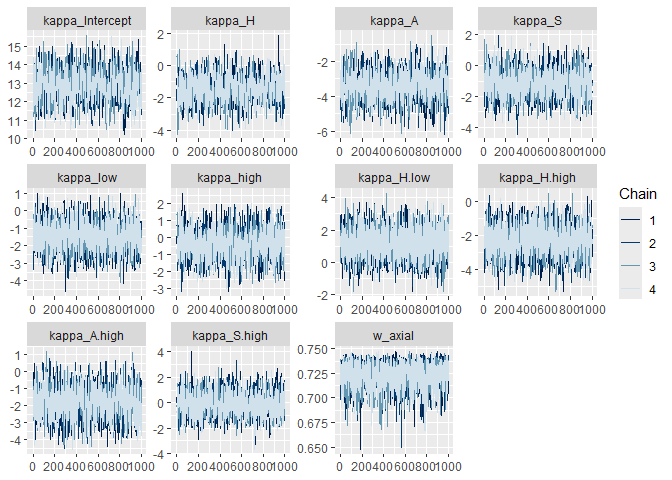

```r
mcmc_trace(draws_final,
           pars = c(grep(paste0('^kappa_', term_pattern), names(draws_final), value = TRUE),
                    intersect('w_axial', names(draws_final))))
```

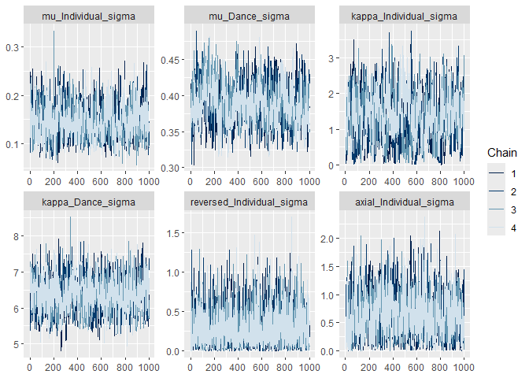

```r
mcmc_trace(draws_final,
           pars = grep('_sigma$', names(draws_final), value = TRUE))
```

Check the $\hat{R}$ values (convergence is indicated by $\hat{R}<1.01$) and the number of chains kept after screening.

```r
print(paste('Chains (after any screening):', n_chains,
            '; divergent transitions:',
            sum(reticulate::py_get_item(idata$sample_stats, 'diverging')$values)))
```

```
## [1] "Chains (after any screening): 4 ; divergent transitions: 0"
```

```r
main_vars = intersect(c('mu_condition', 'mu_cell', 'kappa_Intercept', 'kappa_effect',
                        'reversed_Intercept', 'reversed_effect', 'axial_Intercept', 'axial_effect',
                        'w_axial', 'unrelated_Intercept', 'unrelated_effect',
                        'disoriented_Intercept', 'disoriented_effect',
                        'mu_Individual_sigma', 'mu_Dance_sigma',
                        'kappa_Individual_sigma', 'kappa_Dance_sigma',
                        'reversed_Individual_sigma', 'axial_Individual_sigma'),
                      post_vars)
azsum = az$summary(idata, var_names = as.list(main_vars),
                   circ_var_names = as.list(intersect(c('mu_condition', 'mu_cell'), main_vars)))
print(azsum[, c(1, 3, 4, 7, 9)], digits = 3)
```

```
##                              mean hdi_3% hdi_97% ess_bulk r_hat
## mu_cell[low_vertical]       0.163  0.060   0.261      329  1.01
## mu_cell[low_horizontal]    -0.379 -0.505  -0.253      348  1.02
## mu_cell[medium_vertical]    0.163  0.060   0.261      329  1.01
## mu_cell[medium_horizontal] -0.421 -0.543  -0.307      546  1.00
## mu_cell[medium_antisolar]  -0.073 -0.385   0.325      121  1.05
## mu_cell[medium_solar]       0.461  0.198   0.751      801  1.01
## mu_cell[high_vertical]      0.163  0.060   0.261      329  1.01
## mu_cell[high_horizontal]   -0.335 -0.577  -0.087      290  1.01
## mu_cell[high_antisolar]     0.450  0.250   0.658     1355  1.00
## mu_cell[high_solar]         0.501  0.254   0.764      367  1.01
## kappa_Intercept            12.874 11.251  14.380      754  1.00
## kappa_effect[H]            -1.461 -2.882  -0.007      887  1.00
## kappa_effect[A]            -3.401 -5.001  -2.016     1153  1.00
## kappa_effect[S]            -1.183 -2.788   0.402     1218  1.00
## kappa_effect[low]          -1.494 -2.909   0.020     1602  1.00
## kappa_effect[high]         -0.381 -2.076   1.072     1252  1.00
## kappa_effect[H:low]         1.197 -0.420   2.744     3287  1.00
## kappa_effect[H:high]       -2.313 -3.868  -0.608     1305  1.00
## kappa_effect[A:high]       -1.853 -3.599  -0.244     1172  1.00
## kappa_effect[S:high]       -0.036 -1.759   1.548     1614  1.00
## reversed_Intercept         -4.346 -5.743  -3.100     2263  1.00
## reversed_effect[H]          1.539 -0.052   2.904     1929  1.00
## reversed_effect[A]          0.567 -1.061   1.974     2815  1.00
## reversed_effect[S]          4.046  2.274   5.890     3915  1.00
## reversed_effect[low]       -0.226 -2.256   1.704     1926  1.00
## reversed_effect[high]       0.882 -0.731   2.703     2505  1.00
## reversed_effect[H:low]      0.988 -1.360   3.255     1309  1.00
## reversed_effect[H:high]     2.808  0.957   4.651     2447  1.00
## reversed_effect[A:high]    -2.357 -4.149  -0.612     2653  1.00
## reversed_effect[S:high]     1.267 -0.902   3.533     7762  1.00
## axial_Intercept            -3.668 -4.865  -2.479     2132  1.00
## axial_effect[H]             1.262 -0.097   2.667     1731  1.00
## axial_effect[A]             1.908  0.468   3.375     1523  1.00
## axial_effect[S]             0.130 -1.826   2.168     4410  1.00
## axial_effect[low]           0.301 -1.355   1.805     1843  1.00
## axial_effect[high]         -0.903 -2.976   1.238     1333  1.00
## axial_effect[H:low]         2.853  1.113   4.659     1368  1.00
## axial_effect[H:high]       -0.190 -2.557   2.138      700  1.01
## axial_effect[A:high]       -0.381 -2.874   1.908     1327  1.00
## axial_effect[S:high]       -0.301 -2.866   2.428     8903  1.00
## w_axial                     0.723  0.700   0.744     1054  1.00
## unrelated_Intercept        -3.485 -4.550  -2.387     2037  1.00
## unrelated_effect[H]         0.269 -1.249   1.557      858  1.00
## unrelated_effect[A]        -0.082 -1.791   1.590     2187  1.00
## unrelated_effect[S]        -0.435 -2.157   1.164     3951  1.00
## unrelated_effect[low]      -0.246 -1.684   1.307      921  1.00
## unrelated_effect[high]      0.316 -1.122   1.791     2090  1.00
## unrelated_effect[H:low]     0.405 -1.238   2.292     1098  1.00
## unrelated_effect[H:high]    0.197 -1.481   1.829     1824  1.00
## unrelated_effect[A:high]   -0.392 -2.185   1.380     4344  1.00
## unrelated_effect[S:high]   -0.286 -2.054   1.432     4835  1.00
## mu_Individual_sigma         0.145  0.086   0.206      629  1.01
## mu_Dance_sigma              0.389  0.340   0.440      282  1.02
## kappa_Individual_sigma      1.293  0.030   2.342      418  1.01
## kappa_Dance_sigma           6.374  5.532   7.218      997  1.00
## reversed_Individual_sigma   0.278  0.000   0.682     2769  1.00
## axial_Individual_sigma      0.613  0.000   1.220      901  1.00
```

# Extract predictions

The posterior is summarised by its median and central $95\%$ interval. For circular quantities, draws are centred on their circular median before calculating quantiles, so that the boundary falls far from the bulk of the estimates.

```r
#A function to find the circular median in (-pi, pi)
MedCDraws = function(x,
                     templ = 'none', #assumes radians
                     medn = 1) #take the 1st median
{
  median.circular( circular(x = mod_circular(x),
                            template = templ)
                                           )[medn]
}
#A function to report circular quantiles in degrees, centred on the circular median
QDegDraws = function(x,
                     probs = c(0.5, 0.025, 0.975))
{
  mx = as.numeric(MedCDraws(x))
  round(deg(
    quantile(mod_circular(x - mx), probs = probs) + mx
  ))
}
#A function to report linear quantiles
QDraws = function(x,
                  probs = c(0.5, 0.025, 0.975),
                  digits = 2)
{
  round(quantile(x, probs = probs),
        digits = digits)
}
#Bounded offset, as in the model (B*tanh(x/B))
Bounded = function(x, bound = pi/3)
{
  bound * tanh(x / bound)
}
#Design row for a group: each term is a product of condition effects (successive differences: H, A, S)
#and band indicators (low, high, relative to medium), e.g. H:high, as in the notebooks
XGroup = function(g, terms)
{
  cnd = group_tab[g, 'condition']
  bnd = group_tab[g, 'band']
  sapply(terms,
         function(term)
         {
           prod(sapply(strsplit(term, ':')[[1]],
                       function(q)
                       {
                         if(q %in% c('H', 'A', 'S')){q %in% cond_effs_all[[cnd]]}else{bnd == q}
                       }))
         })
}
#Population concentration for a group
KappaGroup = function(g)
{
  eta = kappa0
  if(length(kappa_terms)){eta = eta + kappa_eff %*% XGroup(g, kappa_terms)}
  softplus(as.vector(eta))
}
#State probabilities for a group, optionally for an individual: samples x states
#(an outlier state has its own probability, and the other states share the remainder)
StateProbs = function(g, i = NULL)
{
  eta = sapply(main_states,
               function(s)
               {
                 if(s == 'forward'){return(rep(0, n_samp))}
                 e = state_int[[s]]
                 if(!is.null(state_eff[[s]])){e = e + as.vector(state_eff[[s]] %*% XGroup(g, state_terms))}
                 if(!is.null(i)){e = e + ind_state_z[[s]][, i + 1]}
                 e
               })
  eta = matrix(eta, nrow = n_samp) # also for a single (forward) state
  colnames(eta) = main_states
  ps = exp(eta - apply(eta, 1, max)) / rowSums(exp(eta - apply(eta, 1, max)))
  if(length(outlier_states))
  {
    e_out = state_int[[outlier_states]]
    if(!is.null(out_eff)){e_out = e_out + as.vector(out_eff %*% XGroup(g, state_terms))}
    p_out = plogis(e_out)
    ps = cbind(ps * (1 - p_out), p_out)
  }
  ps
}
#Panels for plots by group: one row of conditions, or for the joint model one row per band
#(empty panels where a band has no dances in that condition)
panel_layout = if(joint)
{
  matrix(sapply(bands_all, function(b){ifelse(paste(b, conds, sep = '_') %in% groups, paste(b, conds, sep = '_'), NA)}),
         nrow = length(bands_all), byrow = TRUE)
}else
{
  matrix(groups, nrow = 1)
}
ForPanels = function(fun, ...)
{
  par(mfrow = dim(panel_layout), ...)
  for(g in t(panel_layout)){if(is.na(g)){plot.new()}else{fun(g)}}
}
#Expected weight of the forward direction (mu1) in a dance, given its state probabilities:
#forward dances put all runs at mu1, axial dances a proportion w, reversed dances none.
#Outlier (unrelated or disoriented) dances are not oriented to the feeder axis, so w1 is the
#proportion among the other dances
WForward = function(ps, w = w_axial)
{
  w1 = ps[, 'forward'] + if('axial' %in% colnames(ps)){w * ps[, 'axial']}else{0}
  if(length(outlier_states)){w1 = w1 / (1 - ps[, outlier_states])}
  w1
}
```

## Population-level predictions for each condition

For a typical individual (individual effects at zero): the forward direction ($\mu_1$, with the reverse direction $\mu_2 = \mu_1 + 180°$), concentration ($\kappa$, and mean vector length $\rho = A_1(\kappa)$), the probability of each state, and the expected proportion of waggle runs towards $\mu_1$, $w_1 = \pi_\text{forward} + w\,\pi_\text{axial}$ (with an outlier state, the proportion among dances not in it, $w_1 / (1 - \pi_\text{out})$).

```r
pop_draws = lapply(setNames(groups, groups),
                   function(g)
                   {
                     ps = StateProbs(g)
                     colnames(ps) = model_states
                     list(mu = mu_grp[, g],
                          kappa = KappaGroup(g),
                          p = ps,
                          w1 = WForward(ps))
                   })

pred_table = do.call(rbind,
                     lapply(groups,
                            function(g)
                            {
                              pd = pop_draws[[g]]
                              mq = QDegDraws(pd$mu)
                              kq = QDraws(pd$kappa)
                              rq = QDraws(A1(pd$kappa), digits = 3)
                              data.frame(group = g,
                                         mu_median = mq[1], mu_lower = mq[2], mu_upper = mq[3],
                                         kappa_median = kq[1], kappa_lower = kq[2], kappa_upper = kq[3],
                                         rho_median = rq[1], rho_lower = rq[2], rho_upper = rq[3],
                                         row.names = NULL)
                            }
                     )
)
print(pred_table)
```

```
##                group mu_median mu_lower mu_upper kappa_median kappa_lower
## 1       low_vertical         9        3       15        11.39        9.51
## 2     low_horizontal       -22      -30      -14        11.11        9.13
## 3    medium_vertical         9        3       15        12.88       11.26
## 4  medium_horizontal       -24      -31      -17        11.41        9.79
## 5   medium_antisolar        -6      -20       23         8.00        6.16
## 6       medium_solar        26       10       43         6.82        4.64
## 7      high_vertical         9        3       15        12.48       10.37
## 8    high_horizontal       -19      -34       -4         8.71        6.64
## 9     high_antisolar        26       13       38         3.50        1.62
## 10        high_solar        28       15       46         2.33        0.62
##    kappa_upper rho_median rho_lower rho_upper
## 1        13.20      0.955     0.946     0.961
## 2        13.06      0.954     0.944     0.961
## 3        14.53      0.960     0.955     0.965
## 4        12.99      0.955     0.947     0.961
## 5        10.00      0.935     0.915     0.949
## 6         9.13      0.923     0.884     0.944
## 7        14.53      0.959     0.950     0.965
## 8        10.82      0.941     0.921     0.953
## 9         5.51      0.841     0.624     0.904
## 10        4.70      0.745     0.294     0.886
```

```r
state_table = do.call(rbind,
                      lapply(groups,
                             function(g)
                             {
                               do.call(rbind,
                                       lapply(c(model_states, 'w1'),
                                              function(s)
                                              {
                                                x = if(s == 'w1'){pop_draws[[g]]$w1}else{pop_draws[[g]]$p[, s]}
                                                q = QDraws(x, digits = 3)
                                                data.frame(group = g, quantity = s,
                                                           median = q[1], lower = q[2], upper = q[3],
                                                           row.names = NULL)
                                              }))
                             }))
print(state_table)
```

```
##                group  quantity median lower upper
## 1       low_vertical   forward  0.919 0.808 0.972
## 2       low_vertical  reversed  0.011 0.001 0.057
## 3       low_vertical     axial  0.033 0.005 0.125
## 4       low_vertical unrelated  0.025 0.004 0.099
## 5       low_vertical        w1  0.976 0.927 0.995
## 6     low_horizontal   forward  0.279 0.136 0.449
## 7     low_horizontal  reversed  0.057 0.001 0.170
## 8     low_horizontal     axial  0.583 0.404 0.741
## 9     low_horizontal unrelated  0.056 0.002 0.231
## 10    low_horizontal        w1  0.762 0.673 0.835
## 11   medium_vertical   forward  0.926 0.858 0.965
## 12   medium_vertical  reversed  0.012 0.003 0.044
## 13   medium_vertical     axial  0.024 0.006 0.073
## 14   medium_vertical unrelated  0.030 0.009 0.080
```

[output cut: 36 more lines]

```r
print(paste('Axial weight w (proportion of runs towards mu1 in axial dances):',
            paste(QDraws(w_axial, digits = 3), collapse = ', ')))
```

```
## [1] "Axial weight w (proportion of runs towards mu1 in axial dances): 0.725, 0.693, 0.742"
```

## State probabilities by condition

Bars show the population-level probability of each state in each group (median and $95\%$ interval, typical individual); points show the mean posterior state probability across the observed dances in that group.

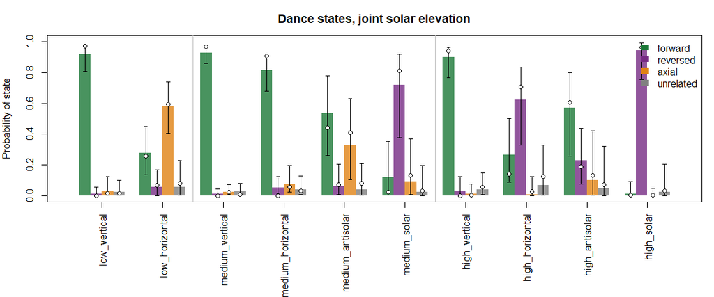

```r
#mean posterior state probability across observed dances
p_state_mean = apply(p_state, c(2, 3), mean) # dances x states
p_state_mean = matrix(p_state_mean, nrow = n_dance, dimnames = list(NULL, model_states))
par(mar = c(if(joint){8}else{4}, 4, 3, 1))
plot(NULL, xlim = c(0.5, length(groups) + 0.5), ylim = c(0, 1), xaxt = 'n',
     xlab = '', ylab = 'Probability of state',
     main = paste('Dance states,', params$elevation, 'solar elevation'))
axis(1, at = seq_along(groups), labels = groups, las = if(joint){2}else{1})
if(joint){abline(v = cumsum(table(group_tab$band)[bands_all])[-length(bands_all)] + 0.5, col = 'gray')}
width = 0.75 / length(model_states)
for(j in seq_along(model_states))
{
  s = model_states[j]
  xs = seq_along(groups) + (j - (length(model_states) + 1) / 2) * width
  q = sapply(groups, function(g){quantile(pop_draws[[g]]$p[, s], c(0.5, 0.025, 0.975))})
  rect(xs - width / 2, 0, xs + width / 2, q[1, ], col = adjustcolor(state_cols[[s]], alpha.f = 0.8), border = NA)
  arrows(xs, q[2, ], xs, q[3, ], angle = 90, code = 3, length = 0.03)
  obs = sapply(groups, function(g){mean(p_state_mean[dance_tab$group == g, s])})
  points(xs, obs, pch = 21, bg = 'white')
}
legend('topright', legend = model_states, fill = unlist(state_cols[model_states]), border = NA, bty = 'n')
```

## Effects of condition on states, direction and concentration

Contrasts between successive conditions (the model effects H, A, S) and between each condition and vertical, for a typical individual. For the joint model, these are made within each elevation band, followed by contrasts between each band and the medium band for each condition. $P(>0)$ is the posterior probability that the quantity increases.

```r
#condition contrasts within a set of groups ordered by condition (vertical first)
CondContrasts = function(gs)
{
  if(length(gs) < 2){return(list())}
  c(lapply(gs[-1], function(g){c(g, gs[1])}),
    if(length(gs) > 2){lapply(3:length(gs), function(k){c(gs[k], gs[k - 1])})})
}
contrasts = if(joint)
{
  c(do.call(c, lapply(bands_all, function(b){CondContrasts(groups[group_tab$band == b])})),
    do.call(c, lapply(conds,
                      function(cnd)
                      {
                        lapply(intersect(paste(c('low', 'high'), cnd, sep = '_'), groups),
                               function(g){c(g, paste('medium', cnd, sep = '_'))})
                      })))
}else
{
  CondContrasts(groups)
}
names(contrasts) = sapply(contrasts, paste, collapse = ' - ')
contrast_table = do.call(rbind,
                         lapply(names(contrasts),
                                function(cname)
                                {
                                  cn = contrasts[[cname]]
                                  p1 = pop_draws[[cn[1]]]; p0 = pop_draws[[cn[2]]]
                                  rows = lapply(c(model_states, 'w1', 'kappa', 'mu (°)'),
                                                function(q)
                                                {
                                                  d = switch(q,
                                                             w1 = p1$w1 - p0$w1,
                                                             kappa = p1$kappa - p0$kappa,
                                                             `mu (°)` = mod_circular(p1$mu - p0$mu),
                                                             p1$p[, q] - p0$p[, q])
                                                  qq = if(q == 'mu (°)'){QDegDraws(d)}else{QDraws(d, digits = 3)}
                                                  data.frame(contrast = cname, quantity = q,
                                                             median = qq[1], lower = qq[2], upper = qq[3],
                                                             P_greater_0 = round(mean(d > 0), 3),
                                                             row.names = NULL)
                                                })
                                  do.call(rbind, rows)
                                }))
print(contrast_table)
```

```
##                                 contrast  quantity  median   lower   upper
## 1          low_horizontal - low_vertical   forward  -0.631  -0.782  -0.455
## 2          low_horizontal - low_vertical  reversed   0.040  -0.015   0.154
## 3          low_horizontal - low_vertical     axial   0.542   0.364   0.699
## 4          low_horizontal - low_vertical unrelated   0.025  -0.037   0.192
## 5          low_horizontal - low_vertical        w1  -0.210  -0.297  -0.137
## 6          low_horizontal - low_vertical     kappa  -0.267  -2.301   1.714
## 7          low_horizontal - low_vertical    mu (°) -31.000 -39.000 -23.000
## 8    medium_horizontal - medium_vertical   forward  -0.106  -0.236  -0.015
## 9    medium_horizontal - medium_vertical  reversed   0.037  -0.002   0.108
## 10   medium_horizontal - medium_vertical     axial   0.049  -0.009   0.165
## 11   medium_horizontal - medium_vertical unrelated   0.009  -0.036   0.087
## 12   medium_horizontal - medium_vertical        w1  -0.055  -0.133  -0.009
## 13   medium_horizontal - medium_vertical     kappa  -1.474  -2.965   0.056
## 14   medium_horizontal - medium_vertical    mu (°) -33.000 -42.000 -25.000
```

[output cut: 225 more lines]

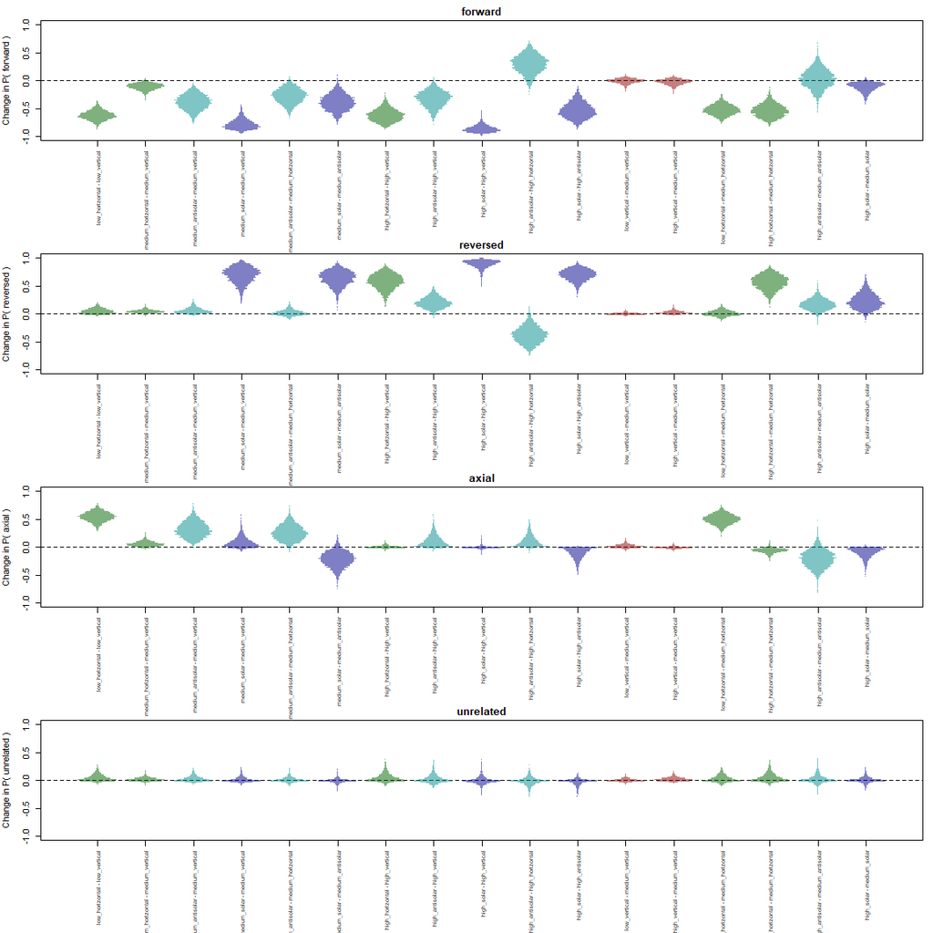

```r
if(joint)
{
  par(mfrow = c(length(model_states), 1), mar = c(9, 4, 2, 1))
}else
{
  par(mfrow = c(1, length(model_states)), mar = c(5, 4, 3, 1))
}
for(s in model_states)
{
  dl = lapply(contrasts, function(cn){pop_draws[[cn[1]]]$p[, s] - pop_draws[[cn[2]]]$p[, s]})
  plot(NULL, xlim = c(0.5, length(dl) + 0.5), ylim = c(-1, 1), xaxt = 'n',
       xlab = '', ylab = paste('Change in P(', s, ')'), main = s)
  if(joint)
  {
    axis(1, at = seq_along(dl), labels = names(dl), cex.axis = 0.7, las = 2)
  }else
  {
    axis(1, at = seq_along(dl), labels = gsub(' - ', '\n- ', names(dl)), cex.axis = 0.7, padj = 0.5)
  }
  abline(h = 0, lty = 2)
  for(k in seq_along(dl))
  {
    hst = hist(dl[[k]], breaks = seq(-1, 1, by = 0.02), plot = FALSE)
    dens = 0.4 * hst$density / max(hst$density)
    rect(k - dens, head(hst$breaks, -1), k + dens, hst$breaks[-1],
         col = adjustcolor(GroupCol(contrasts[[k]][1]), alpha.f = 0.5), border = NA)
  }
}
```

## Extracting individual- and dance-specific predictions

**Individuals**: for each individual in each group in which it danced, the forward direction ($\mu_c$ plus the individual’s offset) and state probabilities (including the individual’s random effects on the state logits), from which the expected proportion of runs towards $\mu_1$ ($w_1$) is calculated.

**Dances**: each dance’s forward direction and concentration from the model, and its *posterior* state probabilities given its own waggle runs.

```r
mu_id = kappa_id = w1_id = matrix(NA, nrow = n_ind, ncol = length(groups), dimnames = list(NULL, groups))
individual_draws = vector('list', n_ind)
for(i in id_tab$Individual)
{
  individual_draws[[i + 1]] = list(mu = list(), kappa = list(), w1 = list())
  for(g in groups[id_group[id_tab$Individual == i, ]])
  {
    off = mu_ind[, i + 1]
    mu_i = mu_grp[, g] + if(bounded_dirs){Bounded(off)}else{off}
    ps = StateProbs(g, i = i)
    colnames(ps) = model_states
    w1 = WForward(ps)
    kp = KappaGroup(g)
    individual_draws[[i + 1]]$mu[[g]] = mu_i
    individual_draws[[i + 1]]$kappa[[g]] = kp
    individual_draws[[i + 1]]$w1[[g]] = w1
    mu_id[i + 1, g] = MedCDraws(mu_i)
    kappa_id[i + 1, g] = median(kp)
    w1_id[i + 1, g] = median(w1)
  }
}

#dances: forward direction, concentration and posterior expected weight towards mu1
mu_dance_med = apply(mu_dance, 2, function(x){as.numeric(MedCDraws(x))})
kappa_dance_med = apply(kappa_dance, 2, median)
ps_d = p_state_mean
w1_dance = WForward(ps_d, w = median(w_axial))
dance_tab = within(dance_tab,
                   {
                     state_map = model_states[apply(ps_d, 1, which.max)]
                     state_prob = apply(ps_d, 1, max)
                   })
print(table(dance_tab$group, factor(dance_tab$state_map, levels = model_states)))
```

```
##
##                     forward reversed axial unrelated
##   low_vertical           34        0     0         0
##   low_horizontal         17        6    41         1
##   medium_vertical        47        0     1         0
##   medium_horizontal      38        0     1         1
##   medium_antisolar       10        1     9         1
##   medium_solar            0       11     1         0
##   high_vertical          20        0     0         1
##   high_horizontal         2       16     0         1
##   high_antisolar         25        4     1         0
##   high_solar              0       22     0         0
```

```r
print(paste('Dances assigned with probability < 0.8:', sum(dance_tab$state_prob < 0.8), 'of', n_dance))
```

```
## [1] "Dances assigned with probability < 0.8: 62 of 312"
```

### Visualising individual predictions

For each bee in each condition (for the joint model, only the cells in which it danced): the observed waggle runs, density contours for the population-level mean vector of each mode in that condition (forward mode in red-yellow, reverse mode in blue, opacity scaled by its weight), thin lines for each dance’s two modes, and arrows for the individual’s two modes. Each mode is drawn with length $A_1(\kappa)$ and line width scaled by its weight ($w_1$ and $1 - w_1$), following `PlotMV_circMLE`, with a minimum width of 0.5 so that minor modes remain visible; opacity is also scaled by weight (minimum 25%), so that many overlapping minor modes do not look like a major one.

```r
#Plot separate mean vectors for each mode (mu1 and mu1 + pi), each of length A1(kappa),
#with line width scaled by the weight of that mode (as in PlotMV_circMLE: lwd = 5 * weight1)
ModeArrows = function(mu, kappa, w1, col, lwd = 5, lwd_min = 0.5, length = 0, alpha = 200/255)
{
  mus = c(mu, mod_circular(mu + pi))
  ws = c(w1, 1 - w1)
  for(md in 1:2)
  {
    arrows.circular(
      x = circular(mus[md], units = 'radians', rotation = 'clock', zero = pi/2),
      y = A1(kappa),
      lwd = max(lwd_min, lwd * ws[md]),
      length = length,
      #fade minor modes too, so that overlapping thin lines do not look like a major mode
      col = adjustcolor(col, alpha.f = alpha * max(0.25, ws[md]))
    )
  }
}
#Posterior density contours for the mean vector of each mode, opacity scaled by its weight
ModeContours = function(mu, kappa, w1)
{
  dl = list(mu = mu, kappa = kappa)
  w_med = median(w1)
  Draws2Cont(dl, alpha = 200/255 * w_med,
             x_string = 'sin(mu) * A1(kappa)', y_string = 'cos(mu) * A1(kappa)')
  Draws2Cont(dl, palette = 'Blues 3', alpha = 200/255 * (1 - w_med),
             x_string = '-sin(mu) * A1(kappa)', y_string = '-cos(mu) * A1(kappa)')
}
```

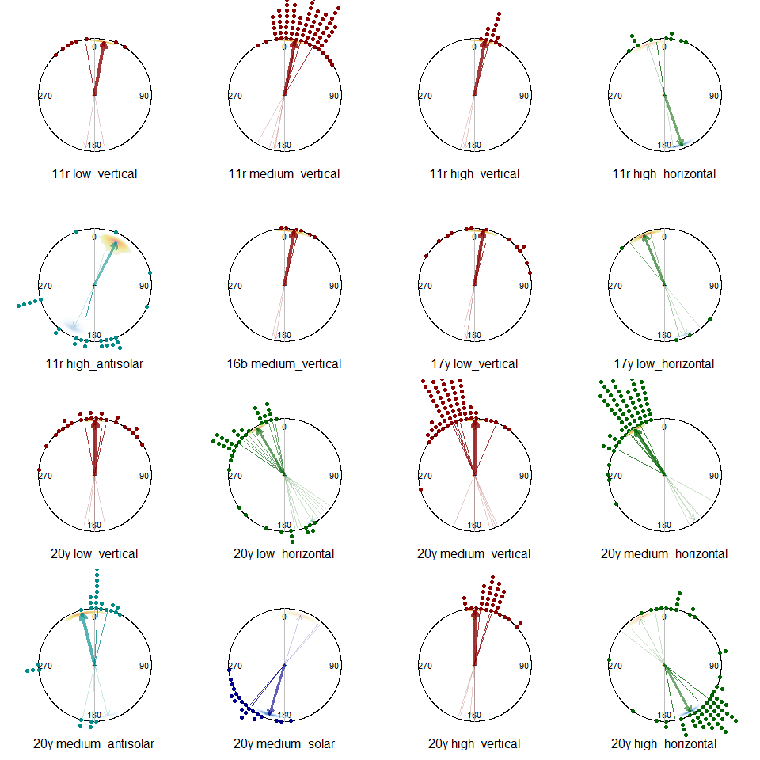

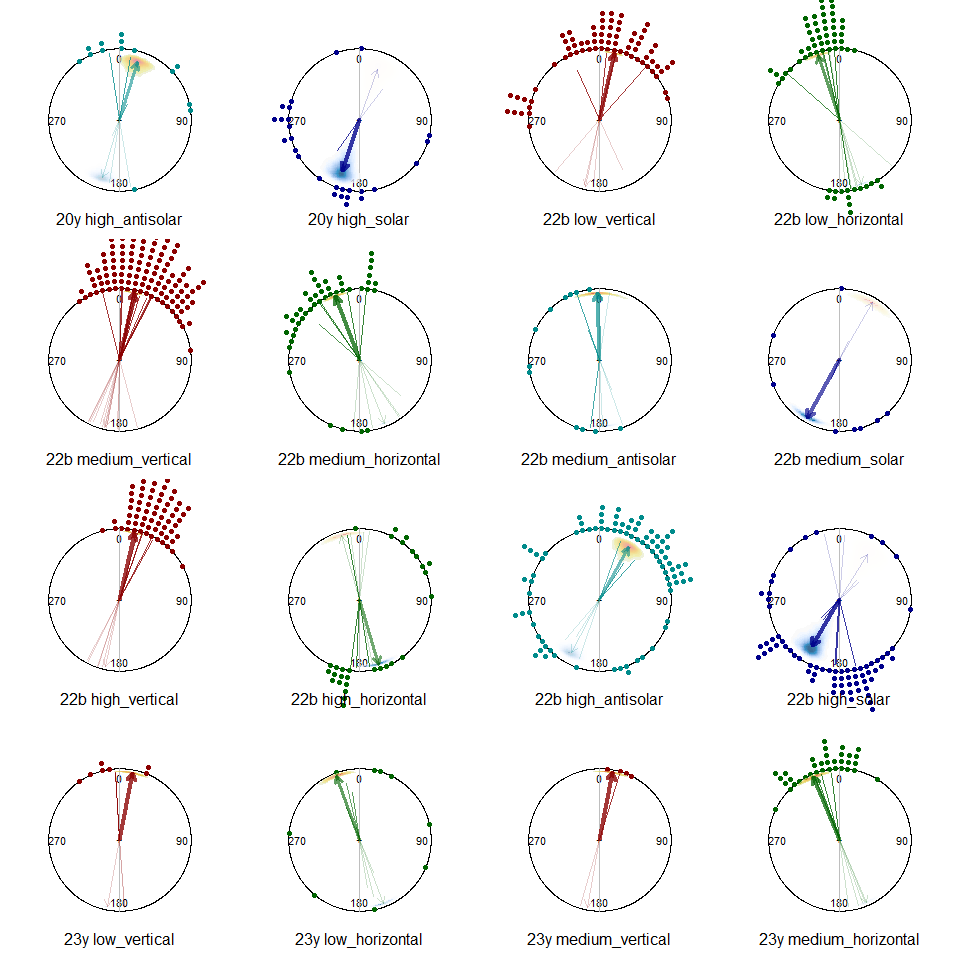

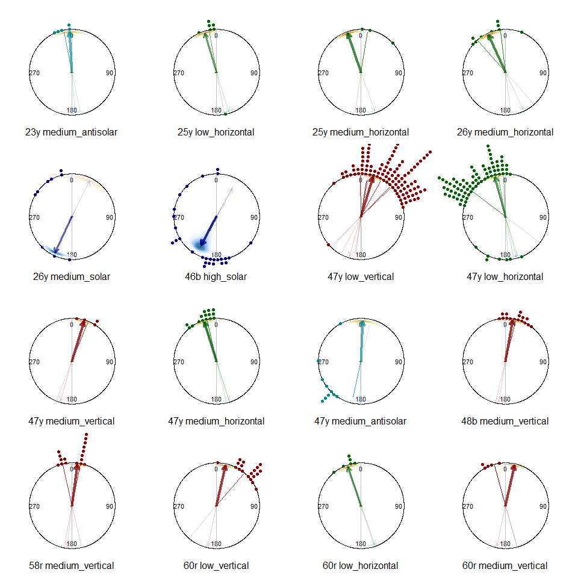

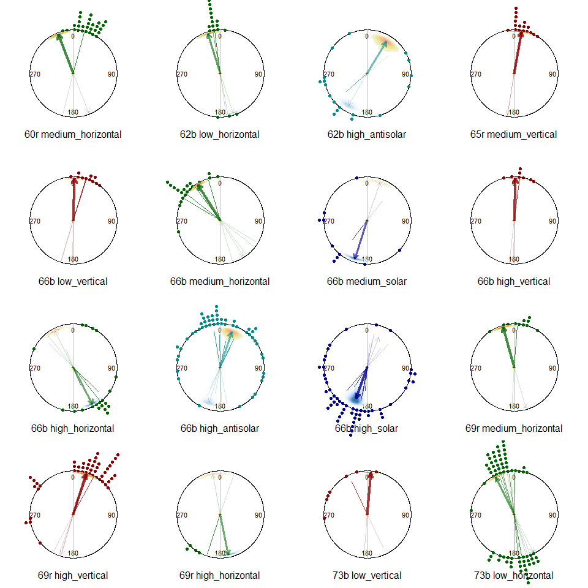

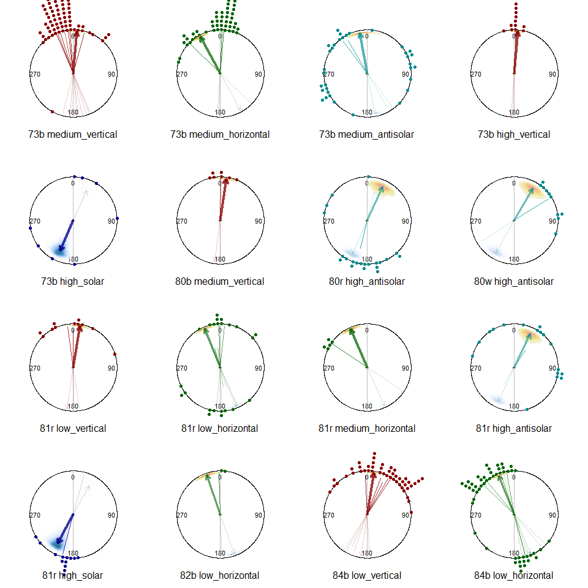

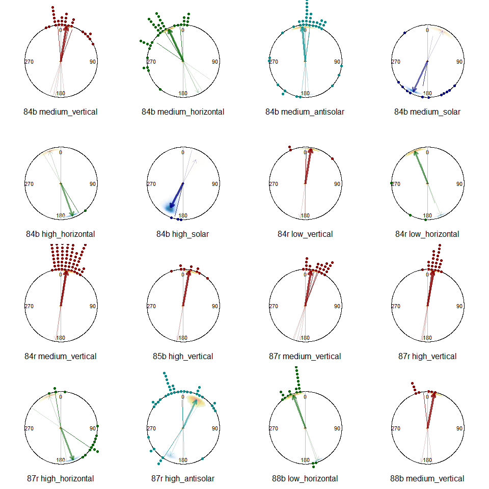

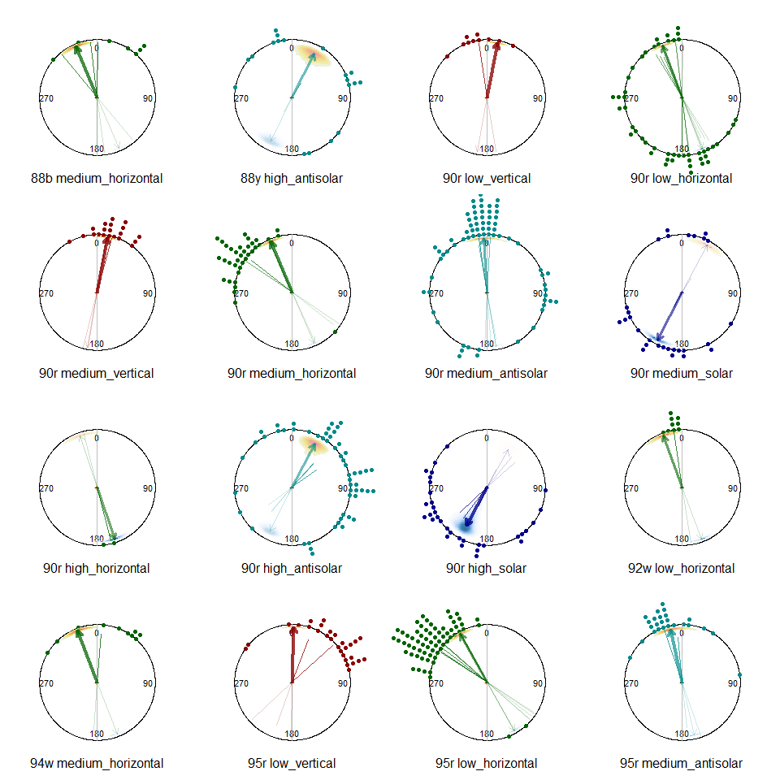

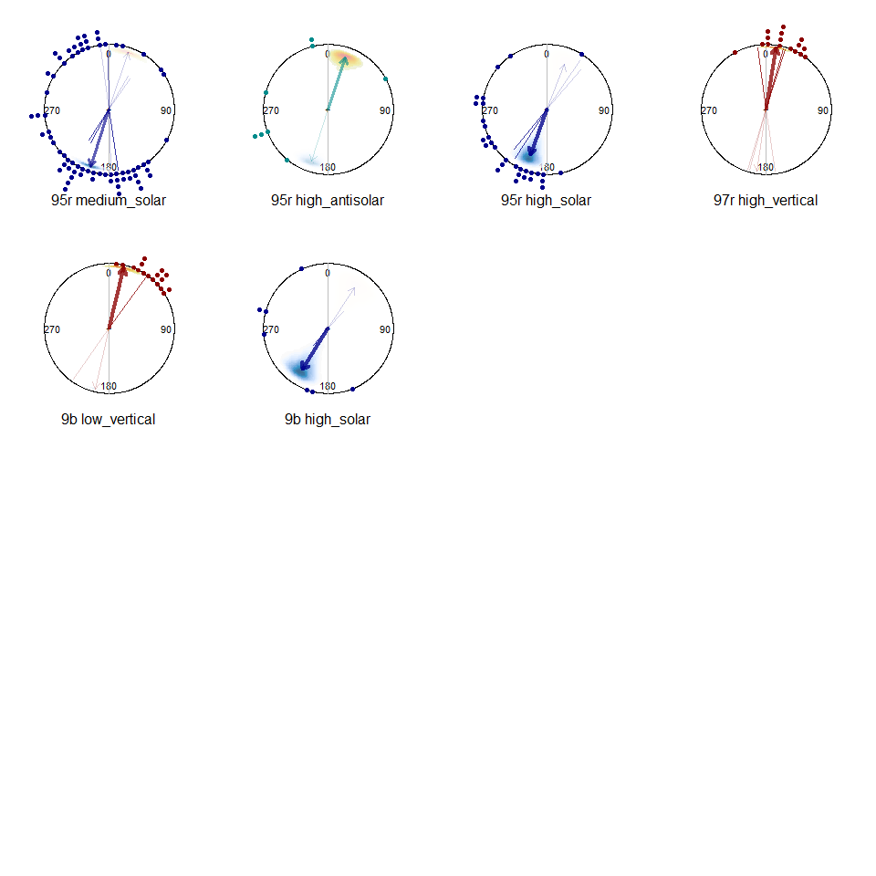

```r
par(pty = 's')
par(mar = c(0,0,0,0),
    mfrow = c(4,4) )
for(i in id_tab$Individual)
{
  indiv = as.character(id_tab$Individual_label[id_tab$Individual == i])
  for(g in if(joint){groups[id_group[id_tab$Individual == i, ]]}else{groups})
  {
    dt_ic = subset(hd, Individual == i & group %in% g)
    if(!nrow(dt_ic))
    {
      plot.new()
      mtext(text = paste(indiv, '\nno', g, 'dances'), side = 1, line = -2)
      next
    }
    PCfun(angles = dt_ic$angle_deg, col = GroupCol(g), plot_rho = FALSE,
          title = paste(indiv, g))
    ModeContours(individual_draws[[i + 1]]$mu[[g]],
                 individual_draws[[i + 1]]$kappa[[g]],
                 individual_draws[[i + 1]]$w1[[g]])
    for(d in unique(dt_ic$Dance))
    {
      ModeArrows(mu_dance_med[d + 1], kappa_dance_med[d + 1], w1_dance[d + 1],
                 col = GroupCol(g), lwd = 2)
    }
    ModeArrows(mu_id[i + 1, g], kappa_id[i + 1, g], w1_id[i + 1, g],
               col = GroupCol(g), lwd = 5, length = 0.1/1.25, alpha = 0.8)
  }
}
```

## Plot population level predictions

For each group: all waggle runs, each individual’s two modes (thin lines), posterior density contours for the population’s two modes, and the population’s median modes (thick arrows).

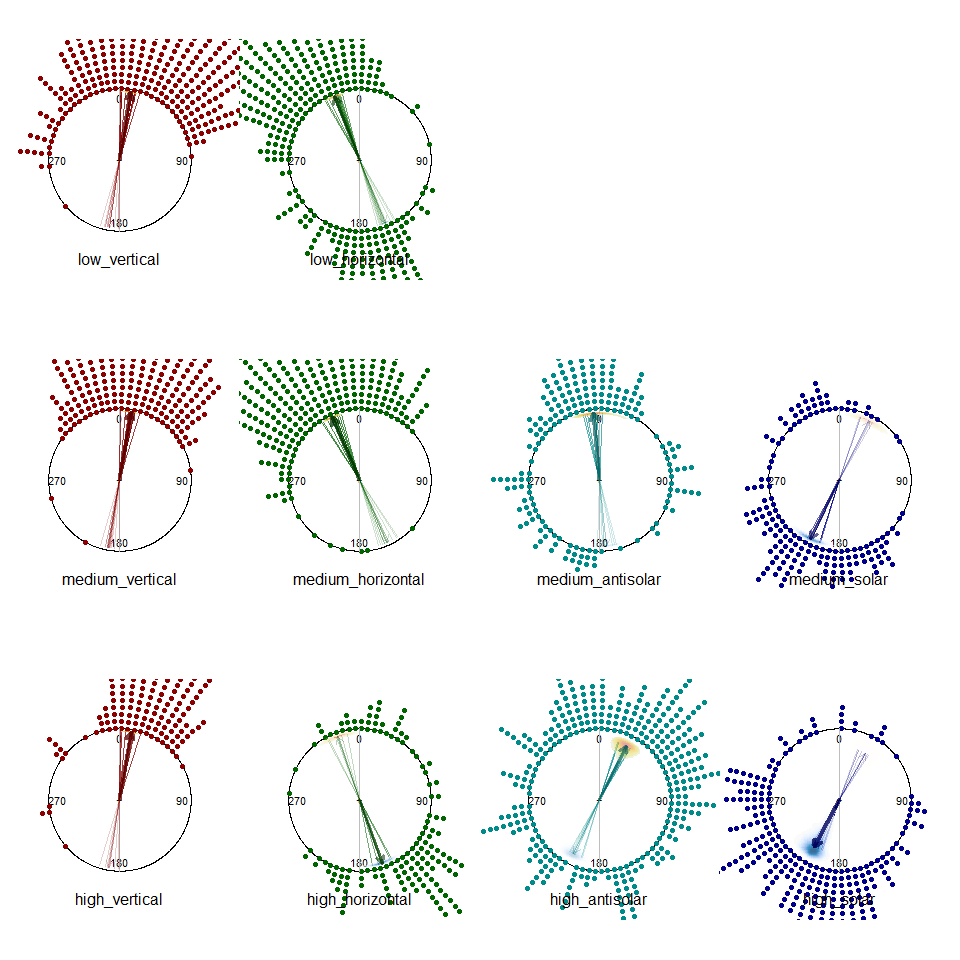

```r
par(pty = 's')
ForPanels(function(g)
{
  PCfun(angles = subset(hd, group %in% g)$angle_deg, col = GroupCol(g),
        shrink = 1.5, plot_rho = FALSE, title = g)
  for(i in id_tab$Individual[id_group[, g]])
  {
    ModeArrows(mu_id[i + 1, g], kappa_id[i + 1, g], w1_id[i + 1, g],
               col = GroupCol(g), lwd = 2)
  }
  pd = pop_draws[[g]]
  ModeContours(pd$mu, pd$kappa, pd$w1)
  ModeArrows(MedCDraws(pd$mu), median(pd$kappa), median(pd$w1),
             col = adjustcolor(GroupCol(g), offset = c(rep(-0.2, 3), 0)),
             lwd = 5, length = 0.1/1.25)
}, mar = c(0,0,0,0))
```

```r
for(g in groups)
{
  print(paste(g, 'forward direction (mu1), degrees:', paste(QDegDraws(pop_draws[[g]]$mu), collapse = ', ')))
}
```

```
## [1] "low_vertical forward direction (mu1), degrees: 9, 3, 15"
## [1] "low_horizontal forward direction (mu1), degrees: -22, -30, -14"
## [1] "medium_vertical forward direction (mu1), degrees: 9, 3, 15"
## [1] "medium_horizontal forward direction (mu1), degrees: -24, -31, -17"
## [1] "medium_antisolar forward direction (mu1), degrees: -6, -20, 23"
## [1] "medium_solar forward direction (mu1), degrees: 26, 10, 43"
## [1] "high_vertical forward direction (mu1), degrees: 9, 3, 15"
## [1] "high_horizontal forward direction (mu1), degrees: -19, -34, -4"
## [1] "high_antisolar forward direction (mu1), degrees: 26, 13, 38"
## [1] "high_solar forward direction (mu1), degrees: 28, 15, 46"
```

## Dance-level state assignments

Each dance’s posterior state probabilities against its unimodal ($R_1$) and axial ($R_2$) mean resultant lengths. Colours mix the state colours in proportion to the posterior probability of each state, and point size scales with the number of waggle runs.

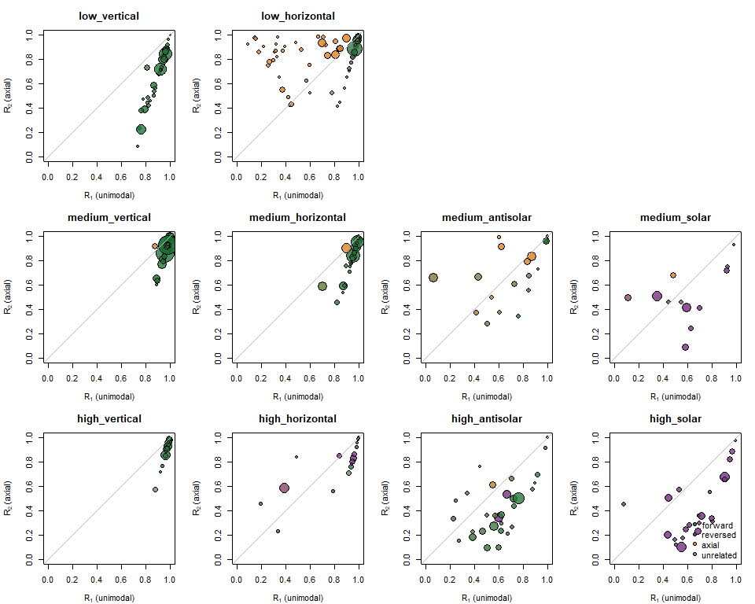

```r
dance_stats = do.call(rbind,
                      lapply(split(hd$angle, hd$Dance),
                             function(a)
                             {
                               data.frame(R1 = Mod(mean(exp(1i * a))),
                                          R2 = Mod(mean(exp(2i * a))),
                                          n_runs = length(a))
                             }))
dance_tab = cbind(dance_tab, dance_stats[as.character(dance_tab$Dance), ])
par(pty = 's')
ForPanels(function(g)
{
  sel = dance_tab$group == g
  rgb_mix = ps_d[sel, , drop = FALSE] %*% t(col2rgb(unlist(state_cols[model_states]))) / 255
  plot(dance_tab$R1[sel], dance_tab$R2[sel], xlim = c(0, 1), ylim = c(0, 1),
       pch = 21, bg = rgb(rgb_mix[, 1], rgb_mix[, 2], rgb_mix[, 3], alpha = 0.8),
       cex = 0.6 + 0.08 * dance_tab$n_runs[sel],
       xlab = expression(R[1] ~ '(unimodal)'), ylab = expression(R[2] ~ '(axial)'), main = g)
  abline(a = 0, b = 1, col = 'gray')
}, mar = c(4, 4, 3, 1))
legend('bottomright', legend = model_states, pt.bg = unlist(state_cols[model_states]), pch = 21, bty = 'n')
```

## Dance-level predictions

Pooling waggle runs from different dances can hide how well each dance is described, so here each dance is plotted separately, ordered by group and individual. Each panel shows the dance’s waggle runs, the dance’s two predicted modes (coloured; forward direction $\mu_d$ and its reverse, each of length $A_1(\kappa_d)$, line width scaled by the expected weight of each mode, $w_1$, given the dance’s posterior state probabilities) and, for reference, the population-level modes for its group (gray). Where the dance is most probably in an outlier state (unrelated or disoriented), its observed mean direction is shown as a dashed gray line instead, since its runs are not expected around $\mu_d$. Each group starts a new figure; panel titles give the individual and dance number (0-based, as in the model), the number of runs, and the most probable state with its posterior probability.

```r
pop_modes = lapply(pop_draws, function(pd){c(mu = MedCDraws(pd$mu), kappa = median(pd$kappa), w1 = median(pd$w1))})
```

[output not shown]

[output cut: 105 more lines]

[output not shown]

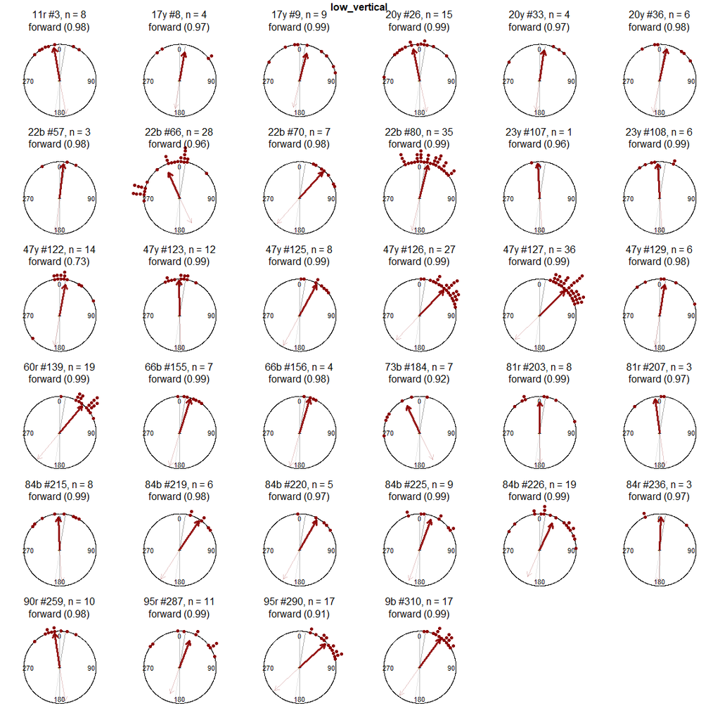

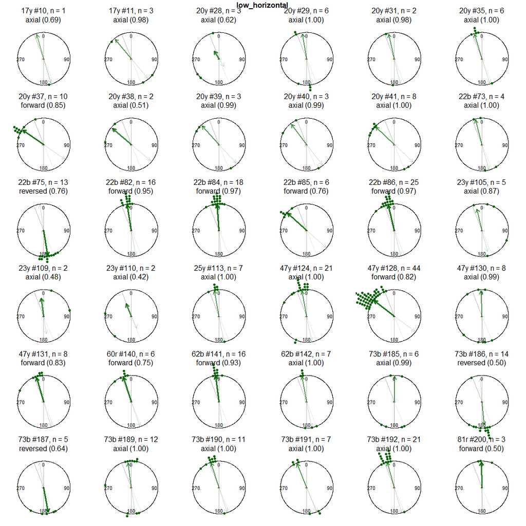

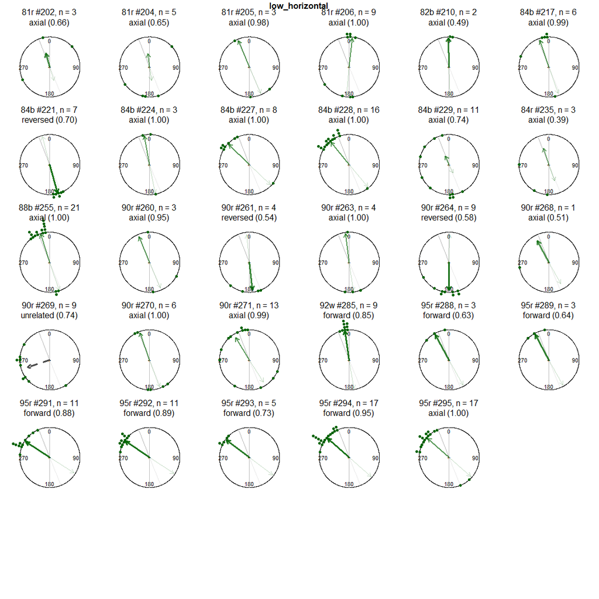

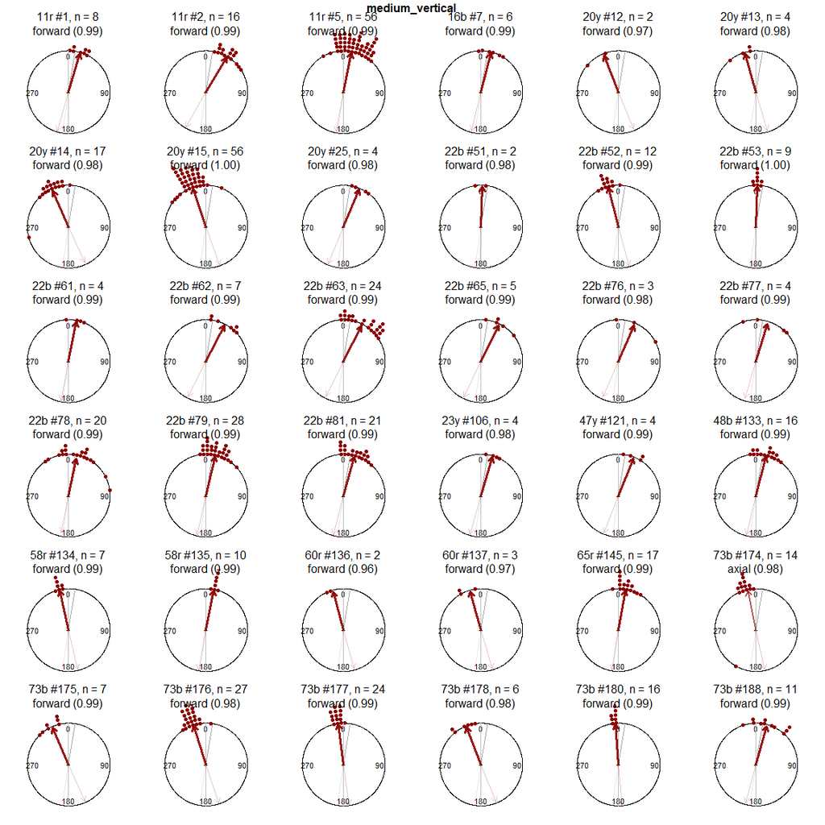

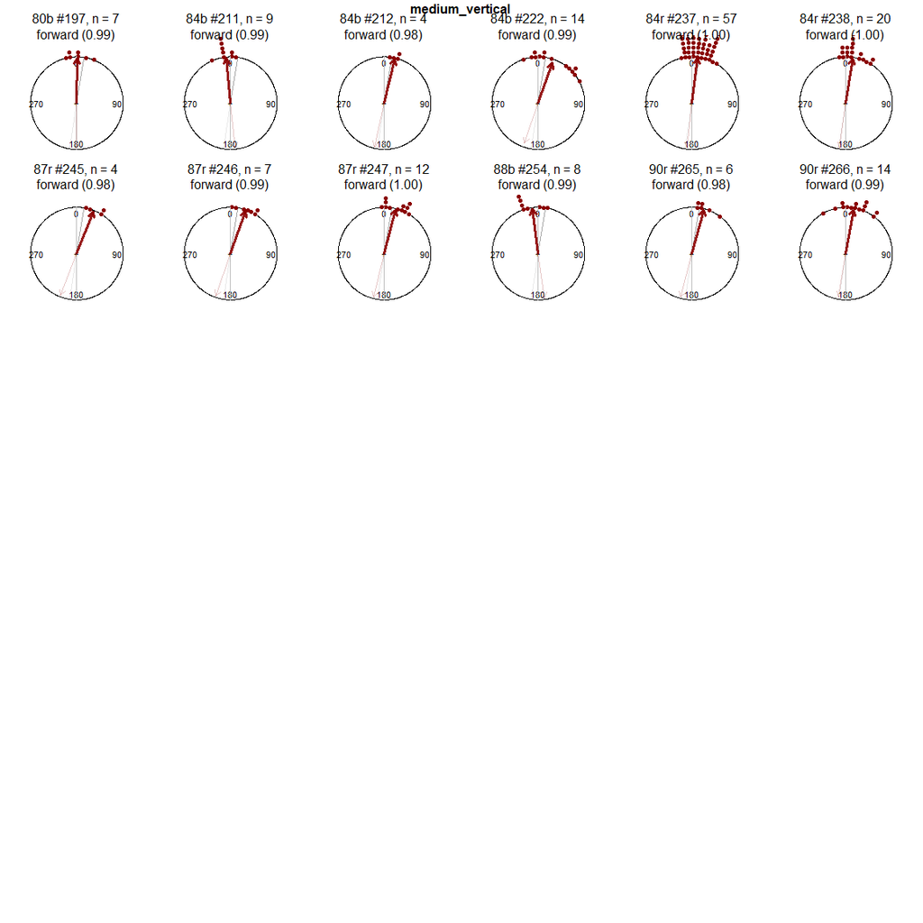

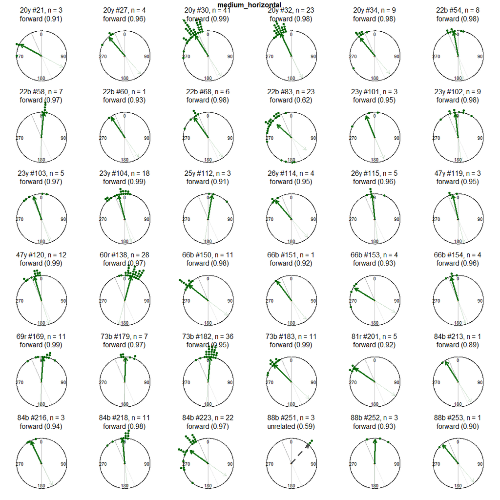

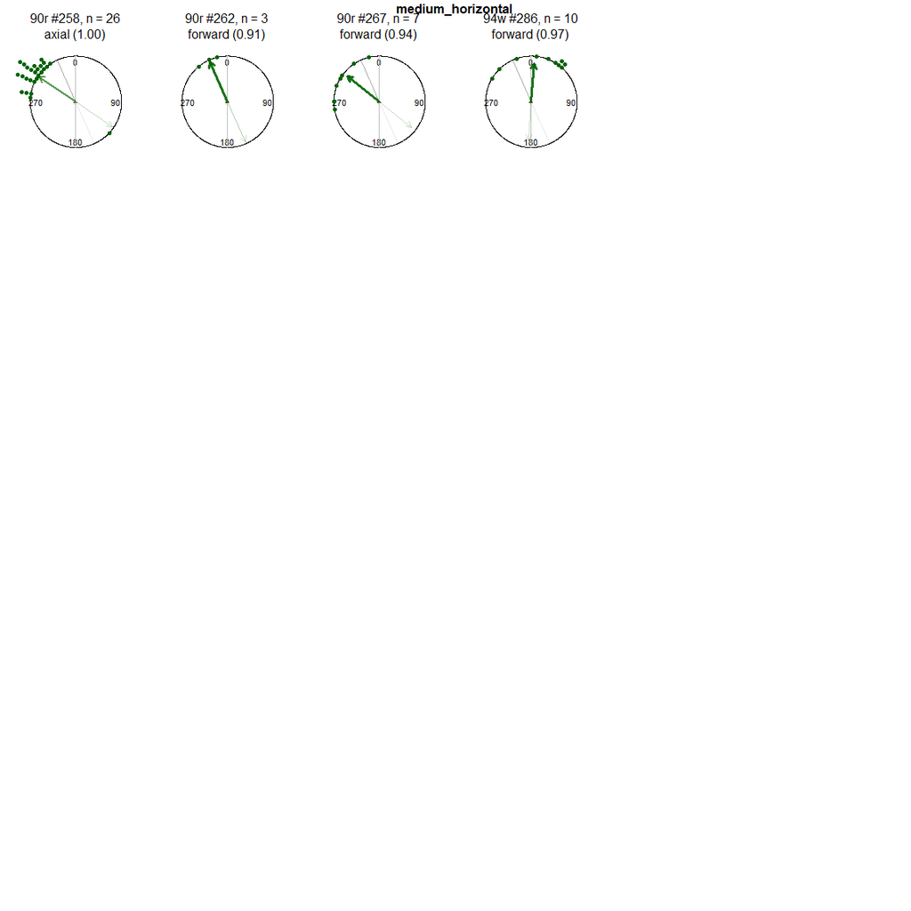

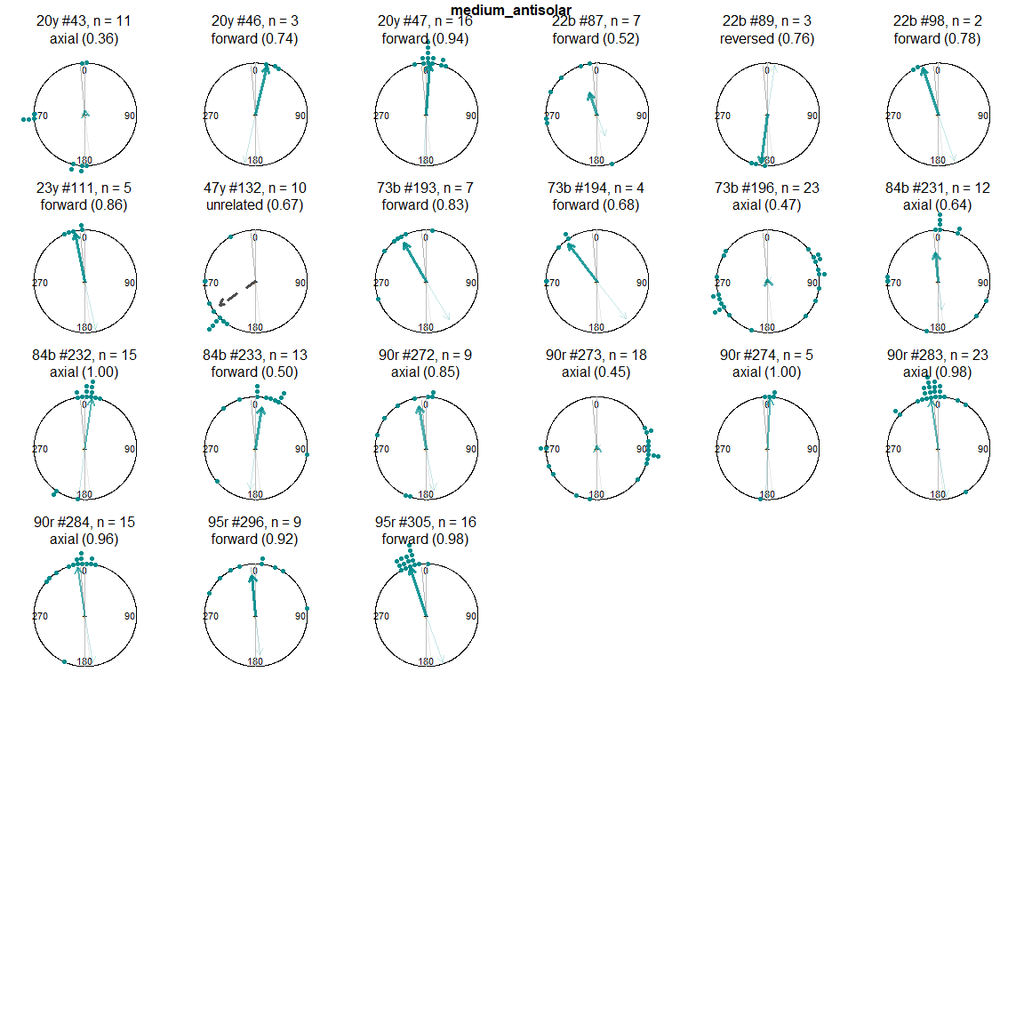

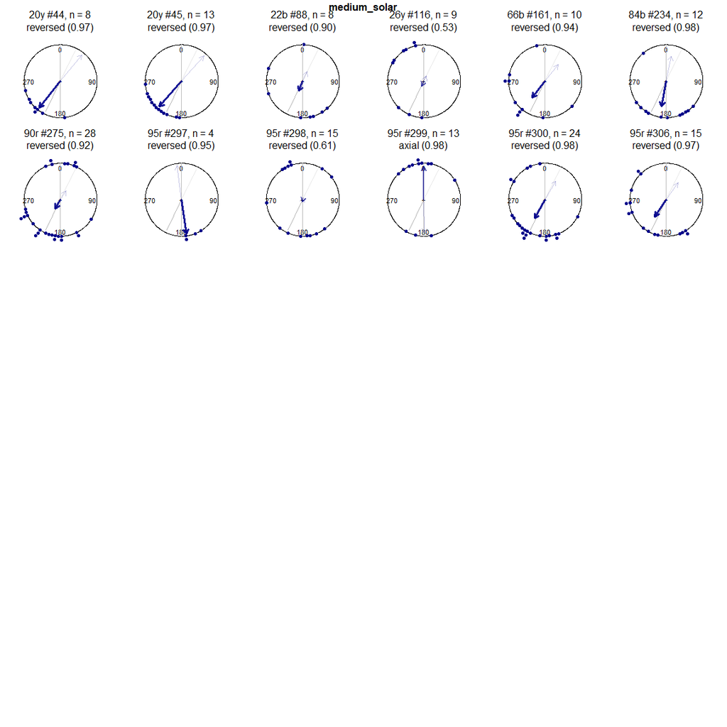

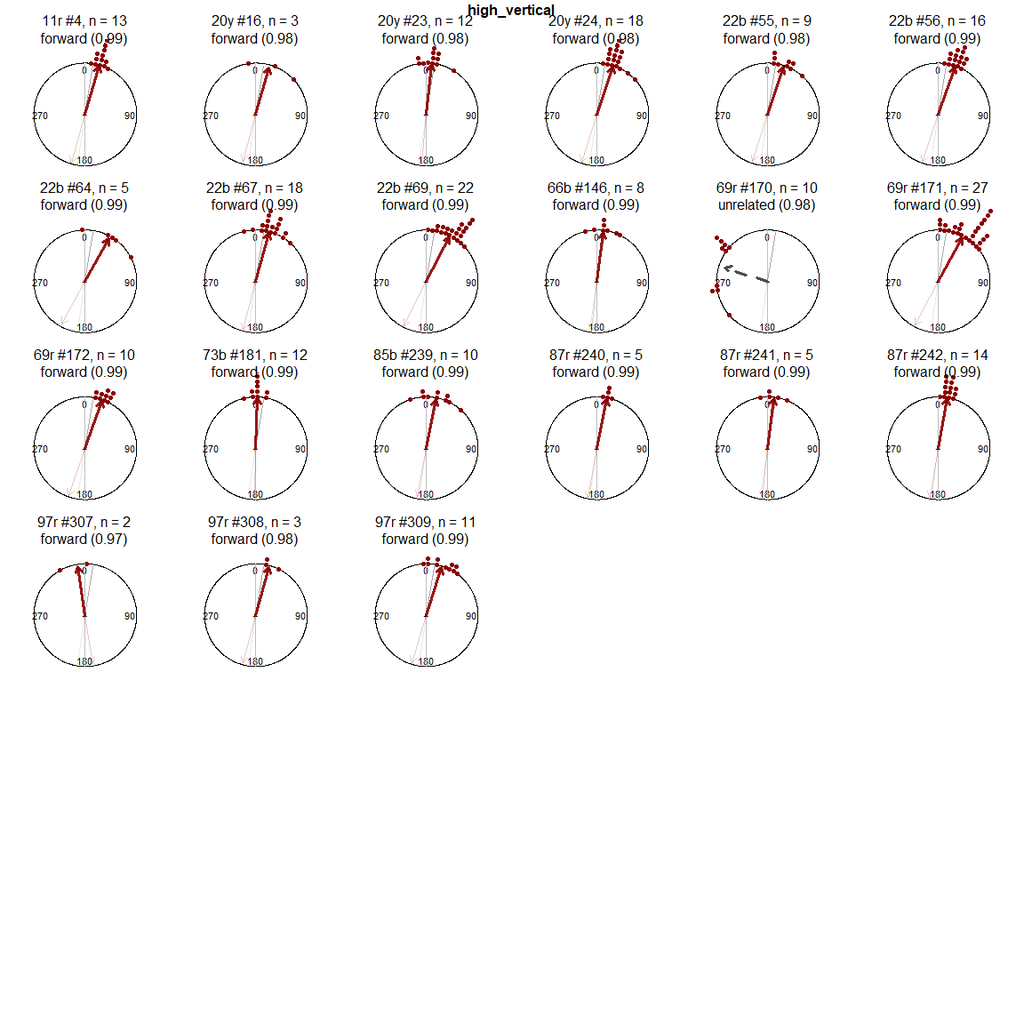

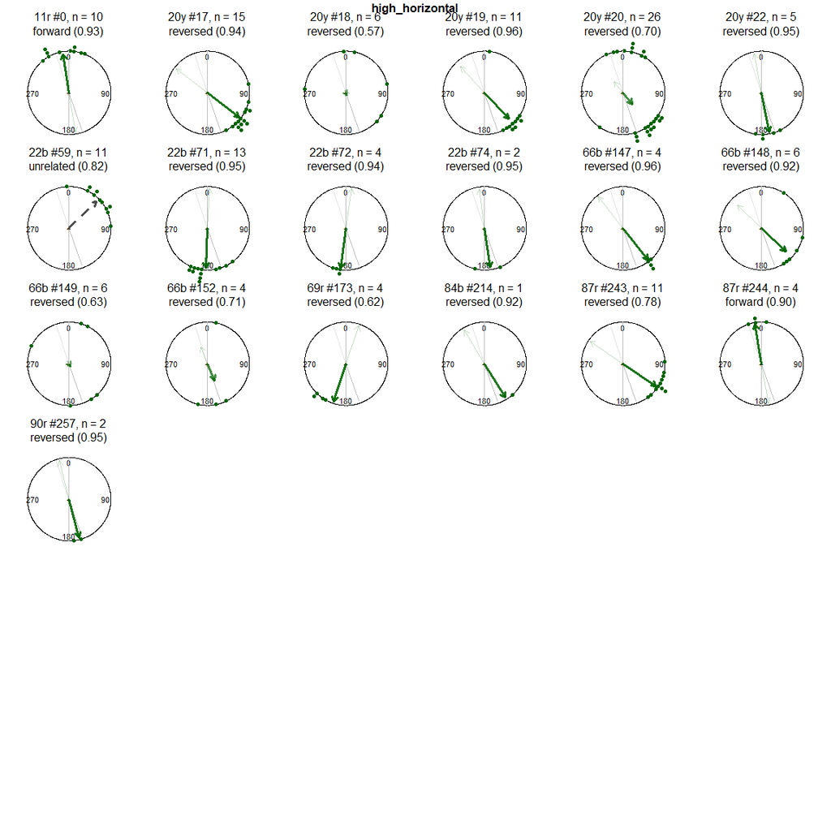

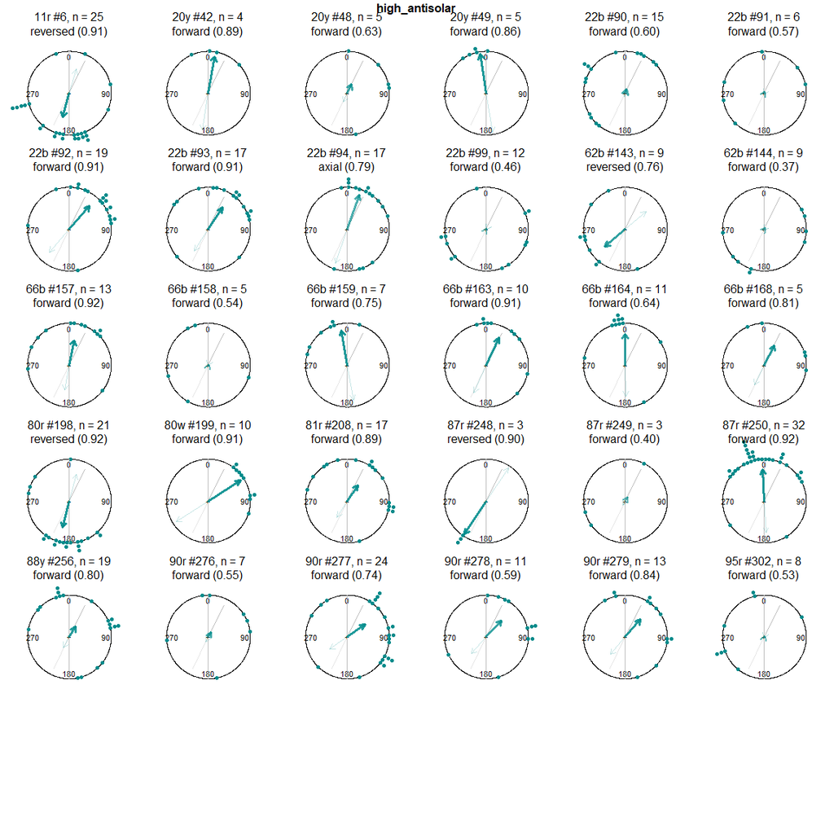

[1 more figures not shown]

```r
for(g in groups)
{
  dance_g = subset(dance_tab, group == g)
  dance_g = dance_g[order(dance_g$Individual_label, dance_g$Dance), ]
  for(k in seq_len(nrow(dance_g)))
  {
    if((k - 1) %% 36 == 0)
    {
      par(pty = 's', mfrow = c(6, 6), mar = c(0, 0, 1.5, 0), oma = c(0, 0, 2, 0))
    }
    dn = dance_g[k, ]
    d = dn$Dance
    runs = subset(hd, Dance == d)$angle_deg
    PCfun(angles = runs, col = GroupCol(g), plot_rho = FALSE, shrink = 1.3,
          title = paste0(dn$Individual_label, ' #', d, ', n = ', length(runs), '\n',
                         dn$state_map, ' (', format(round(dn$state_prob, 2), nsmall = 2), ')'),
          side = 3, titleline = -0.5)
    if((k - 1) %% 36 == 0){mtext(g, side = 3, outer = TRUE, line = 0.5, font = 2)}
    pm = pop_modes[[g]]
    ModeArrows(pm['mu'], pm['kappa'], pm['w1'], col = 'gray40', lwd = 2, alpha = 0.6)
    if(dn$state_map %in% outlier_states)
    {
      z = mean(exp(1i * rad(runs)))
      arrows.circular(x = circular(Arg(z), units = 'radians', rotation = 'clock', zero = pi/2),
                      y = Mod(z), lty = 2, lwd = 3, col = 'gray30', length = 0.08)
    }else
    {
      ModeArrows(mu_dance_med[d + 1], kappa_dance_med[d + 1], w1_dance[d + 1],
                 col = GroupCol(g), lwd = 4, length = 0.08, alpha = 0.9)
    }
  }
}
```

## Concentration

Posterior concentration ($\kappa$) of waggle runs around each mode, for a typical dance in each group.

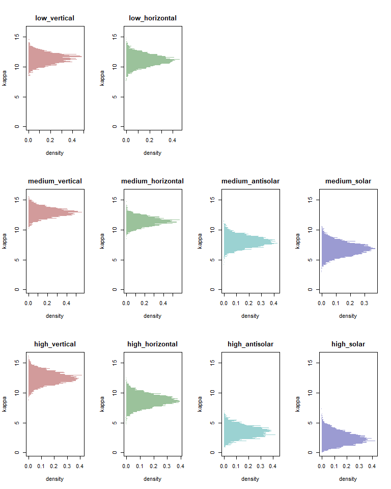

```r
kappa_lim = range(unlist(lapply(pop_draws, `[[`, 'kappa')))
ForPanels(function(g)
{
  VertHist(data = pop_draws[[g]]$kappa,
           main = paste0('\n', g),
           ylab = 'kappa',
           ylim = kappa_lim,
           col = adjustcolor(GroupCol(g), alpha.f = 100/255),
           cex.axis = 0.7)
})
```

```r
print(pred_table[, c('group', 'kappa_median', 'kappa_lower', 'kappa_upper', 'rho_median')])
```

```
##                group kappa_median kappa_lower kappa_upper rho_median
## 1       low_vertical        11.39        9.51       13.20      0.955
## 2     low_horizontal        11.11        9.13       13.06      0.954
## 3    medium_vertical        12.88       11.26       14.53      0.960
## 4  medium_horizontal        11.41        9.79       12.99      0.955
## 5   medium_antisolar         8.00        6.16       10.00      0.935
## 6       medium_solar         6.82        4.64        9.13      0.923
## 7      high_vertical        12.48       10.37       14.53      0.959
## 8    high_horizontal         8.71        6.64       10.82      0.941
## 9     high_antisolar         3.50        1.62        5.51      0.841
## 10        high_solar         2.33        0.62        4.70      0.745
```

## Variation across individuals and dances

Standard deviations of individual and dance offsets in direction (in degrees; for von Mises individual offsets, the circular SD, $\sqrt{-2 \log A_1(\kappa_u)}$), and of individual and dance effects on $\kappa$ and on the state logits.

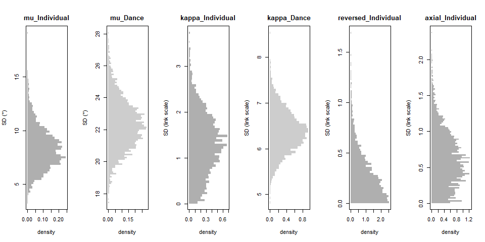

```r
sigma_params = grep('_sigma$', names(draws_final), value = TRUE)
par(mfrow = c(1, length(sigma_params)))
for(sp in sigma_params)
{
  is_mu = grepl('^mu_', sp)
  VertHist(data = if(is_mu){deg(draws_final[[sp]])}else{draws_final[[sp]]},
           main = paste0('\n', gsub('_sigma', '', sp)),
           ylab = if(is_mu){'SD (°)'}else{'SD (link scale)'},
           col = adjustcolor(if(grepl('Dance', sp)){'gray50'}else{'gray20'}, alpha.f = 100/255),
           cex.axis = 0.7)
}
```

```r
sigma_table = do.call(rbind,
                      lapply(sigma_params,
                             function(sp)
                             {
                               is_mu = grepl('^mu_', sp)
                               q = if(is_mu){QDraws(deg(draws_final[[sp]]), digits = 1)}else{QDraws(draws_final[[sp]])}
                               data.frame(parameter = sp, units = if(is_mu){'degrees'}else{'link scale'},
                                          median = q[1], lower = q[2], upper = q[3], row.names = NULL)
                             }))
print(sigma_table)
```

```
##                   parameter      units median lower upper
## 1       mu_Individual_sigma    degrees   8.20  5.20 12.40
## 2            mu_Dance_sigma    degrees  22.20 19.40 25.50
## 3    kappa_Individual_sigma link scale   1.28  0.12  2.59
## 4         kappa_Dance_sigma link scale   6.36  5.52  7.28
## 5 reversed_Individual_sigma link scale   0.23  0.01  0.84
## 6    axial_Individual_sigma link scale   0.58  0.04  1.43
```

# Model comparison

Leave-one-dance-out cross-validation (PSIS-LOO) for the models fitted in `HS_circGLMM_states.ipynb` (or, for the joint model, `HS_circGLMM_states_joint.ipynb`) with the same direction prior. Each dance has its own direction, concentration and state, so leaving one out changes the posterior substantially and PSIS is often unreliable (many dances with Pareto $\hat{k} > 0.7$): treat this as provisional, pending K-fold cross-validation.

```r
model_labels = if(joint)
{
  c(unimodal = 'Unimodal (forward only, unbounded offsets)',
    states_cond = 'States ~ condition',
    states_cond_band = 'States ~ condition + band',
    states_cond_x_band = 'States ~ condition * band',
    states_cond_x_band_fixed = 'States ~ condition * band, directions fixed at the feeder')
}else
{
  c(unimodal = 'Unimodal (forward only, unbounded offsets)',
    two_states = 'Forward/reversed, condition-dependent',
    three_states_same = 'Forward/reversed/axial, same in all conditions',
    three_states_condition = 'Forward/reversed/axial, condition-dependent')
}
model_files = file.path(params$model_dir,
                        paste0('HS_states_', params$elevation, '_', params$direction_prior, '_',
                               names(model_labels), '.nc'))
names(model_files) = model_labels
model_files = model_files[file.exists(model_files)]
az_py = reticulate::import("arviz", convert = FALSE)
loo_list = lapply(model_files, function(f){az_py$loo(az_py$from_netcdf(f))})
if(length(loo_list) > 1)
{
  comparison = reticulate::py_to_r(az_py$compare(reticulate::dict(loo_list), ic = 'loo'))
  print(comparison[, c('rank', 'elpd_loo', 'p_loo', 'elpd_diff', 'weight', 'se', 'dse', 'warning')],
        digits = 3)
}else
{
  print(paste('Only one model fitted with this fit_tag:', names(loo_list)))
}
```

```
##                                                           rank elpd_loo p_loo
## States ~ condition + band                                    0    -2579   559
## States ~ condition * band                                    1    -2580   573
## Unimodal (forward only, unbounded offsets)                   2    -2607   484
## States ~ condition                                           3    -2607   550
## States ~ condition * band, directions fixed at the feeder    4    -2616   567
##                                                           elpd_diff   weight
## States ~ condition + band                                      0.00 2.40e-01
## States ~ condition * band                                      1.04 5.10e-02
## Unimodal (forward only, unbounded offsets)                    27.95 7.09e-01
## States ~ condition                                            28.11 1.26e-12
## States ~ condition * band, directions fixed at the feeder     37.65 0.00e+00
##                                                            se   dse warning
## States ~ condition + band                                 177  0.00    TRUE
## States ~ condition * band                                 177  7.79    TRUE
## Unimodal (forward only, unbounded offsets)                183 47.19    TRUE
## States ~ condition                                        175  9.34    TRUE
## States ~ condition * band, directions fixed at the feeder 178 13.14    TRUE
```

```r
for(nm in names(loo_list))
{
  k = reticulate::py_to_r(loo_list[[nm]]$pareto_k$values)
  print(paste0(nm, ': ', sum(k > 0.7), ' of ', length(k), ' dances with Pareto k > 0.7'))
}
```

```
## [1] "Unimodal (forward only, unbounded offsets): 270 of 312 dances with Pareto k > 0.7"
## [1] "States ~ condition: 236 of 312 dances with Pareto k > 0.7"
## [1] "States ~ condition + band: 241 of 312 dances with Pareto k > 0.7"
## [1] "States ~ condition * band: 237 of 312 dances with Pareto k > 0.7"
## [1] "States ~ condition * band, directions fixed at the feeder: 240 of 312 dances with Pareto k > 0.7"
```